# CAPSTONE PROJECT - SOCIAL MEDIA TOURISM

### Outliers Treatment :- Using Quantile-based Capping and Flooring

In this technique, we will do the flooring (10th percentile) for the lower values and capping (90th percentile) for the higher values. These values will be used for quantile-based flooring and capping.

```python
print('Capping Values:\n\n',data[num_columns].quantile(0.90))
print('\n--------------------\n')
print('Flooring Values:\n\n',data[num_columns].quantile(0.10))
```

```
Capping Values:

 YA_view_on_CP                  383.00
TL_done_on_OS_checkin        47505.80
YA_OS_checkin                   23.00
Members_in_fam                   4.00
YA_comment_on_CP               104.00
TL_rec_on_OS_checkin         13880.20
Week_since_last_OS_checkin       7.00
DA_mins_spend_on_CP             26.00
Name: 0.9, dtype: float64

--------------------

Flooring Values:

 YA_view_on_CP                 202.00
TL_done_on_OS_checkin        8497.80
YA_OS_checkin                   1.00
Members_in_fam                  1.00
YA_comment_on_CP               47.00
TL_rec_on_OS_checkin         2345.00
Week_since_last_OS_checkin      1.00
DA_mins_spend_on_CP             5.00
Name: 0.1, dtype: float64
```

Now after we got the capping and flooring values for each numerical variables, so now we can remove the outliers.

```python
data["YA_view_on_CP"] = np.where(data["YA_view_on_CP"] <202.0, 202.0,data['YA_view_on_CP'])
data["YA_view_on_CP"] = np.where(data["YA_view_on_CP"] >383.0, 383.0,data['YA_view_on_CP'])
print('Skewness for YA_view_on_CP:',data['YA_view_on_CP'].skew())
print('\n------------------------\n')
data["TL_done_on_OS_checkin"] = np.where(data["TL_done_on_OS_checkin"] <8497.80, 8497.80,data['TL_done_on_OS_checkin'])
data["TL_done_on_OS_checkin"] = np.where(data["TL_done_on_OS_checkin"] >47505.80, 47505.80,data['TL_done_on_OS_checkin'])
print('Skewness for TL_done_on_OS_checkin:',data['TL_done_on_OS_checkin'].skew())
print('\n------------------------\n')
data["YA_OS_checkin"] = np.where(data["YA_OS_checkin"] <1.0, 1.0,data['YA_OS_checkin'])
data["YA_OS_checkin"] = np.where(data["YA_OS_checkin"] >23.0, 23.0,data['YA_OS_checkin'])
print('Skewness for YA_OS_checkin:',data['YA_OS_checkin'].skew())
print('\n------------------------\n')
data["Members_in_fam"] = np.where(data["Members_in_fam"] <1.0, 1.0,data['Members_in_fam'])
data["Members_in_fam"] = np.where(data["Members_in_fam"] >4.0, 4.0,data['Members_in_fam'])
print('Skewness for Members_in_fam:',data['Members_in_fam'].skew())
print('\n------------------------\n')
data["YA_comment_on_CP"] = np.where(data["YA_comment_on_CP"] <47.0, 47.0,data['YA_comment_on_CP'])
data["YA_comment_on_CP"] = np.where(data["YA_comment_on_CP"] >104.0, 104.0,data['YA_comment_on_CP'])
print('Skewness for YA_comment_on_CP:',data['YA_comment_on_CP'].skew())
print('\n------------------------\n')
data["TL_rec_on_OS_checkin"] = np.where(data["TL_rec_on_OS_checkin"] <2345.0, 2345.0,data['TL_rec_on_OS_checkin'])
data["TL_rec_on_OS_checkin"] = np.where(data["TL_rec_on_OS_checkin"] >13880.20, 13880.20,data['TL_rec_on_OS_checkin'])
print('Skewness for TL_rec_on_OS_checkin:',data['TL_rec_on_OS_checkin'].skew())
print('\n------------------------\n')
data["Week_since_last_OS_checkin"] = np.where(data["Week_since_last_OS_checkin"] <1.0, 1.0,data['Week_since_last_OS_checkin'])
data["Week_since_last_OS_checkin"] = np.where(data["Week_since_last_OS_checkin"] >7.0, 7.0,data['Week_since_last_OS_checkin'])
print('Skewness for Week_since_last_OS_checkin:',data['Week_since_last_OS_checkin'].skew())
print('\n------------------------\n')
data["DA_mins_spend_on_CP"] = np.where(data["DA_mins_spend_on_CP"] <5.0, 5.0,data['DA_mins_spend_on_CP'])
data["DA_mins_spend_on_CP"] = np.where(data["DA_mins_spend_on_CP"] >26.0, 26.0,data['DA_mins_spend_on_CP'])
print('Skewness for DA_mins_spend_on_CP:',data['DA_mins_spend_on_CP'].skew())
```

```
Skewness for YA_view_on_CP: 0.3573009167056305

------------------------

Skewness for TL_done_on_OS_checkin: -0.002869798276763351

------------------------

Skewness for YA_OS_checkin: 0.7897377414782413

------------------------

Skewness for Members_in_fam: -0.5254672621694083

------------------------

Skewness for YA_comment_on_CP: -0.029205831095984694

------------------------

Skewness for TL_rec_on_OS_checkin: 0.9213182389570522

------------------------

Skewness for Week_since_last_OS_checkin: 0.6401441226417389

------------------------

Skewness for DA_mins_spend_on_CP: 0.49161568807826334
```

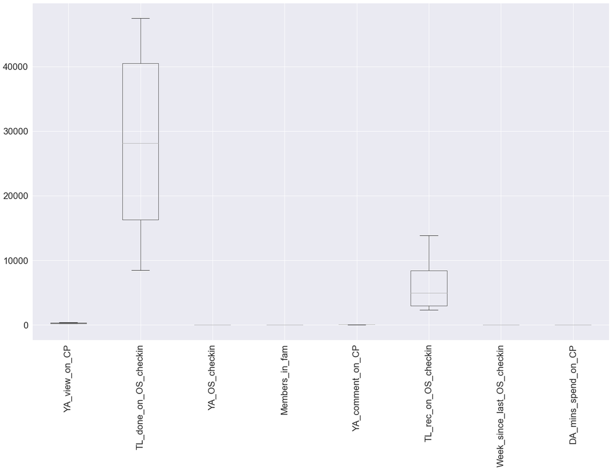

```python
data[num_columns].boxplot(figsize=(25, 15), rot=90)
```

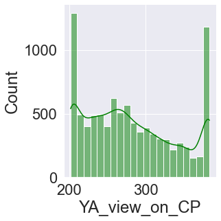

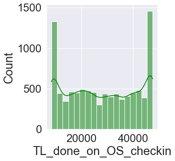

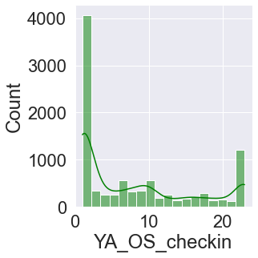

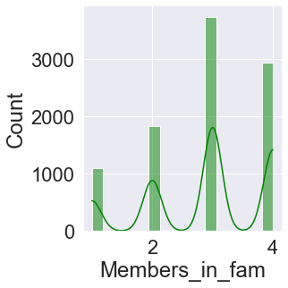

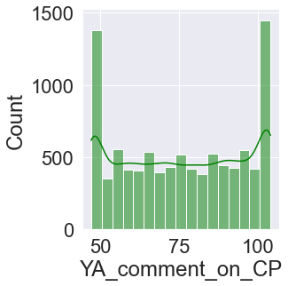

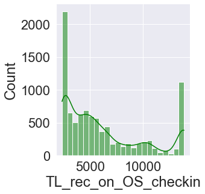

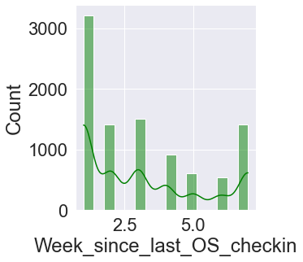

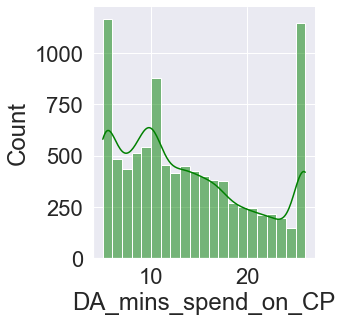

```python
for x in num_columns:
    plt.figure(figsize=(10,8))
    sns.displot(data[x], kde=True, color='green')
    plt.show()
```

```python
data.shape
```

```
(9607, 15)
```

```python
data.describe().T
```

|  | count | mean | std | min | 25% | 50% | 75% | max |
| --- | --- | --- | --- | --- | --- | --- | --- | --- |
| YA_view_on_CP | 9607.00 | 281.39 | 58.63 | 202.00 | 232.00 | 272.00 | 326.00 | 383.00 |
| TL_done_on_OS_checkin | 9607.00 | 28166.12 | 13345.05 | 8497.80 | 16312.50 | 28178.00 | 40542.50 | 47505.80 |
| YA_OS_checkin | 9607.00 | 8.08 | 7.88 | 1.00 | 1.00 | 5.00 | 14.00 | 23.00 |
| Members_in_fam | 9607.00 | 2.89 | 0.97 | 1.00 | 2.00 | 3.00 | 4.00 | 4.00 |
| YA_comment_on_CP | 9607.00 | 75.92 | 19.42 | 47.00 | 58.00 | 76.00 | 94.00 | 104.00 |
| TL_rec_on_OS_checkin | 9607.00 | 6186.89 | 3781.49 | 2345.00 | 2952.50 | 4955.00 | 8412.00 | 13880.20 |
| Week_since_last_OS_checkin | 9607.00 | 3.16 | 2.16 | 1.00 | 1.00 | 3.00 | 5.00 | 7.00 |
| DA_mins_spend_on_CP | 9607.00 | 13.67 | 6.77 | 5.00 | 8.00 | 12.00 | 19.00 | 26.00 |

### Multivariate Analysis :-

### Correlation Matrix to check the multicollinearity in the variables:-

```python
#Now let see the correlation between the variables using correlation matrics

corr = data.corr()

corr
```

|  | YA_view_on_CP | TL_done_on_OS_checkin | YA_OS_checkin | Members_in_fam | YA_comment_on_CP | TL_rec_on_OS_checkin | Week_since_last_OS_checkin | DA_mins_spend_on_CP |
| --- | --- | --- | --- | --- | --- | --- | --- | --- |
| YA_view_on_CP | 1.00 | 0.00 | -0.00 | 0.19 | 0.04 | 0.50 | 0.30 | 0.62 |
| TL_done_on_OS_checkin | 0.00 | 1.00 | 0.00 | -0.01 | 0.02 | 0.01 | 0.03 | 0.02 |
| YA_OS_checkin | -0.00 | 0.00 | 1.00 | 0.01 | 0.05 | -0.00 | -0.04 | 0.00 |
| Members_in_fam | 0.19 | -0.01 | 0.01 | 1.00 | 0.01 | 0.09 | 0.12 | 0.12 |
| YA_comment_on_CP | 0.04 | 0.02 | 0.05 | 0.01 | 1.00 | -0.01 | 0.05 | 0.06 |
| TL_rec_on_OS_checkin | 0.50 | 0.01 | -0.00 | 0.09 | -0.01 | 1.00 | 0.16 | 0.69 |
| Week_since_last_OS_checkin | 0.30 | 0.03 | -0.04 | 0.12 | 0.05 | 0.16 | 1.00 | 0.29 |
| DA_mins_spend_on_CP | 0.62 | 0.02 | 0.00 | 0.12 | 0.06 | 0.69 | 0.29 | 1.00 |

### Heatmap :- for better visualization

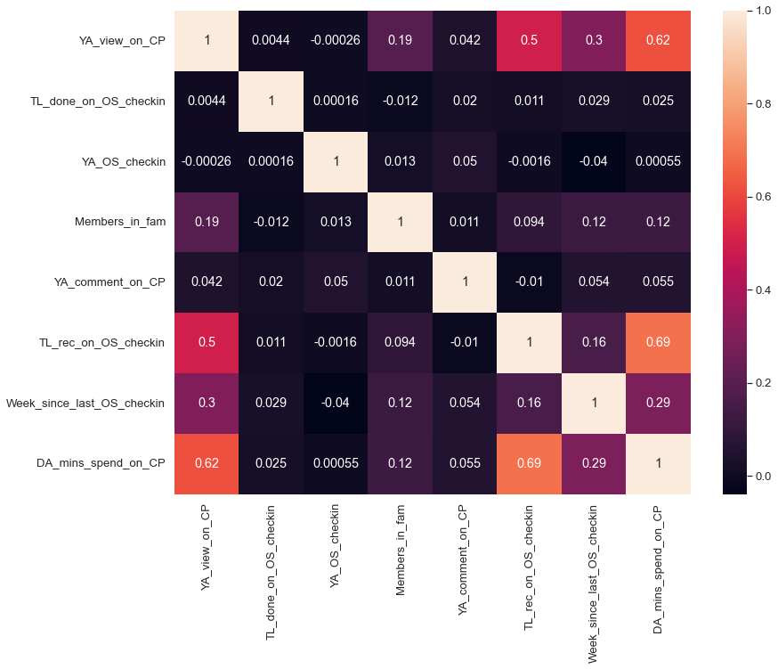

```python
#Now we will plot the heatmap to display the correlation between the variables:

sns.set(font_scale=1.2)
fig, ax = plt.subplots(figsize=(13,10))
sns.heatmap(corr,annot=True)
```

### So here in the above heatmap we can see that the light colours shows the highest correlation between 2 variables.

#### The variables are not highly correlated, however there are some moderately correlation can be observed :-

1. 'TL_rec_on_OS_checkin' and 'DA_mins_spend_on_CP' (0.69)
2. 'YA_view_on_CP' and 'DA_mins_spend_on_CP' (0.62)
3. 'TL_rec_on_OS_checkin' and 'YA_view_on_CP' (0.5)

### PairPlot :-

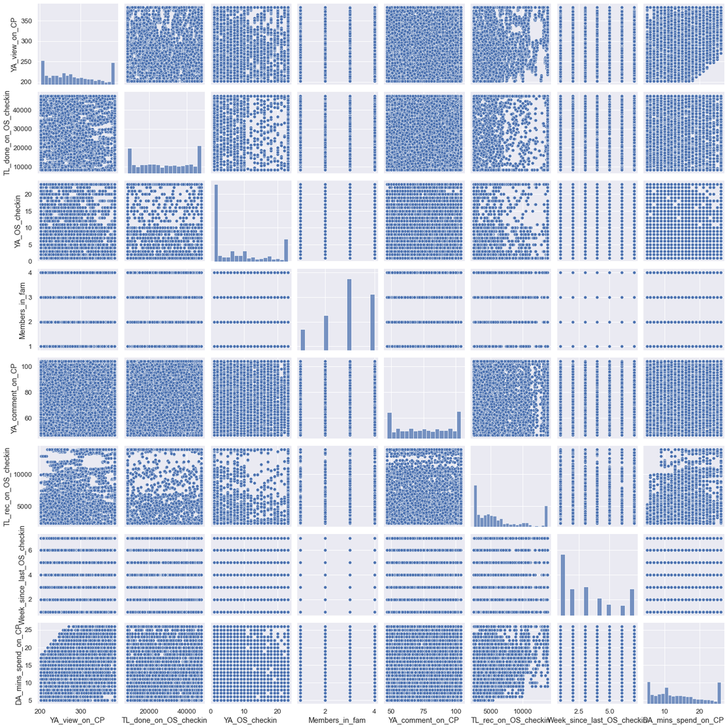

```python
sns.set(font_scale=1.2)
sns.pairplot(data)
```

### Model building and interpretation.

1. Build various models (You can choose to build models for either or all of descriptive, predictive or prescriptive purposes).
2. Test your predictive model against the test set using various appropriate performance metrics c.Interpretation of the model(s).

### Importing the required libraries :-

```python
from sklearn.preprocessing import MinMaxScaler, StandardScaler
from sklearn.model_selection import train_test_split, GridSearchCV
from sklearn.linear_model import LogisticRegression
from sklearn.discriminant_analysis import LinearDiscriminantAnalysis
from imblearn.over_sampling import SMOTE
from sklearn import metrics
from sklearn.metrics import roc_auc_score,roc_curve,classification_report,confusion_matrix,plot_confusion_matrix
from sklearn.neighbors import KNeighborsClassifier
from sklearn.ensemble import GradientBoostingClassifier, AdaBoostClassifier, BaggingClassifier, RandomForestClassifier
from sklearn.naive_bayes import GaussianNB
```

```python
data.head().T
```

|  | 0 | 1 | 2 | 3 | 4 |
| --- | --- | --- | --- | --- | --- |
| Taken_product | Yes | No | Yes | No | No |
| YA_view_on_CP | 307.00 | 367.00 | 277.00 | 247.00 | 202.00 |
| Pref_device | Mobile | Mobile | Mobile | Mobile | Mobile |
| TL_done_on_OS_checkin | 38570.00 | 9765.00 | 47505.80 | 47505.80 | 20685.00 |
| YA_OS_checkin | 1.00 | 1.00 | 1.00 | 1.00 | 1.00 |
| Members_in_fam | 2.00 | 1.00 | 2.00 | 4.00 | 1.00 |
| Pref_loc_type | Financial | Financial | Other | Financial | Medical |
| YA_comment_on_CP | 94.00 | 61.00 | 92.00 | 56.00 | 47.00 |
| TL_rec_on_OS_checkin | 5993.00 | 5130.00 | 2345.00 | 2909.00 | 3468.00 |
| Week_since_last_OS_checkin | 7.00 | 1.00 | 6.00 | 1.00 | 7.00 |
| Following_CP | Yes | No | Yes | Yes | No |
| Working_flag | No | Yes | No | No | No |
| Travelling_network_rating | 1 | 4 | 2 | 3 | 4 |
| Adult_flag | 0 | 1 | 0 | 0 | 1 |
| DA_mins_spend_on_CP | 8.00 | 10.00 | 7.00 | 8.00 | 6.00 |

```python
data.info()
```

```
<class 'pandas.core.frame.DataFrame'>
Int64Index: 9607 entries, 0 to 11759
Data columns (total 15 columns):
 #   Column                      Non-Null Count  Dtype
---  ------                      --------------  -----
 0   Taken_product               9607 non-null   object
 1   YA_view_on_CP               9607 non-null   float64
 2   Pref_device                 9607 non-null   category
 3   TL_done_on_OS_checkin       9607 non-null   float64
 4   YA_OS_checkin               9607 non-null   float64
 5   Members_in_fam              9607 non-null   float64
 6   Pref_loc_type               9607 non-null   object
 7   YA_comment_on_CP            9607 non-null   float64
 8   TL_rec_on_OS_checkin        9607 non-null   float64
 9   Week_since_last_OS_checkin  9607 non-null   float64
 10  Following_CP                9607 non-null   object
 11  Working_flag                9607 non-null   category
 12  Travelling_network_rating   9607 non-null   category
 13  Adult_flag                  9607 non-null   category
 14  DA_mins_spend_on_CP         9607 non-null   float64
dtypes: category(4), float64(8), object(3)
memory usage: 1.2+ MB
```

### We have to build models separately for Laptop and Mobile users : let us make 2 different dataframes for each :-

So, let us first split the dataset into two seperate dataframes.

```python
# data_laptop is the dataset of the users who preferred laptop

data_laptop = data[data['Pref_device'] == 'Laptop']


# data_mobile is the dataset of the users who preferred mobile

data_mobile = data[data['Pref_device'] == 'Mobile']
```

### Head, Shape and Description of data_laptop dataset -

```python
print('Shape of the dataset:',data_laptop.shape)

data_laptop.head().T
```

```
Shape of the dataset: (1108, 15)
```

|  | 5881 | 5883 | 5885 | 5888 | 5906 |
| --- | --- | --- | --- | --- | --- |
| Taken_product | No | No | No | No | Yes |
| YA_view_on_CP | 379.00 | 255.00 | 250.00 | 295.00 | 250.00 |
| Pref_device | Laptop | Laptop | Laptop | Laptop | Laptop |
| TL_done_on_OS_checkin | 9776.00 | 47505.80 | 35184.00 | 8497.80 | 39379.00 |
| YA_OS_checkin | 8.00 | 3.00 | 2.00 | 23.00 | 16.00 |
| Members_in_fam | 1.00 | 4.00 | 2.00 | 3.00 | 1.00 |
| Pref_loc_type | Adventure_and_Tourism | Adventure_and_Tourism | Adventure_and_Tourism | Adventure_and_Tourism | Adventure_and_Tourism |
| YA_comment_on_CP | 64.00 | 59.00 | 84.00 | 48.00 | 80.00 |
| TL_rec_on_OS_checkin | 5142.00 | 2913.00 | 3074.00 | 9532.00 | 3926.00 |
| Week_since_last_OS_checkin | 1.00 | 1.00 | 1.00 | 1.00 | 1.00 |
| Following_CP | No | Yes | No | No | Yes |
| Working_flag | Yes | No | No | Yes | Yes |
| Travelling_network_rating | 4 | 3 | 3 | 2 | 2 |
| Adult_flag | 1 | 0 | 0 | 0 | 0 |
| DA_mins_spend_on_CP | 10.00 | 8.00 | 8.00 | 10.00 | 10.00 |

```python
data_laptop.describe().T
```

|  | count | mean | std | min | 25% | 50% | 75% | max |
| --- | --- | --- | --- | --- | --- | --- | --- | --- |
| YA_view_on_CP | 1108.00 | 281.61 | 56.48 | 202.00 | 237.00 | 270.50 | 325.00 | 383.00 |
| TL_done_on_OS_checkin | 1108.00 | 27755.89 | 12607.79 | 8497.80 | 17650.25 | 26942.50 | 39380.25 | 47505.80 |
| YA_OS_checkin | 1108.00 | 8.93 | 7.72 | 1.00 | 2.00 | 7.00 | 15.00 | 23.00 |
| Members_in_fam | 1108.00 | 2.86 | 0.99 | 1.00 | 2.00 | 3.00 | 4.00 | 4.00 |
| YA_comment_on_CP | 1108.00 | 77.03 | 19.14 | 47.00 | 60.00 | 77.00 | 95.00 | 104.00 |
| TL_rec_on_OS_checkin | 1108.00 | 5995.28 | 3680.14 | 2345.00 | 2884.00 | 4759.50 | 7979.50 | 13880.20 |
| Week_since_last_OS_checkin | 1108.00 | 2.95 | 2.08 | 1.00 | 1.00 | 2.00 | 4.00 | 7.00 |
| DA_mins_spend_on_CP | 1108.00 | 13.36 | 6.77 | 5.00 | 8.00 | 11.50 | 18.00 | 26.00 |

### Head, Shape and Description of data_mobile dataset -

```python
print('Shape of the dataset:',data_mobile.shape)

data_mobile.head().T
```

```
Shape of the dataset: (8499, 15)
```

|  | 0 | 1 | 2 | 3 | 4 |
| --- | --- | --- | --- | --- | --- |
| Taken_product | Yes | No | Yes | No | No |
| YA_view_on_CP | 307.00 | 367.00 | 277.00 | 247.00 | 202.00 |
| Pref_device | Mobile | Mobile | Mobile | Mobile | Mobile |
| TL_done_on_OS_checkin | 38570.00 | 9765.00 | 47505.80 | 47505.80 | 20685.00 |
| YA_OS_checkin | 1.00 | 1.00 | 1.00 | 1.00 | 1.00 |
| Members_in_fam | 2.00 | 1.00 | 2.00 | 4.00 | 1.00 |
| Pref_loc_type | Financial | Financial | Other | Financial | Medical |
| YA_comment_on_CP | 94.00 | 61.00 | 92.00 | 56.00 | 47.00 |
| TL_rec_on_OS_checkin | 5993.00 | 5130.00 | 2345.00 | 2909.00 | 3468.00 |
| Week_since_last_OS_checkin | 7.00 | 1.00 | 6.00 | 1.00 | 7.00 |
| Following_CP | Yes | No | Yes | Yes | No |
| Working_flag | No | Yes | No | No | No |
| Travelling_network_rating | 1 | 4 | 2 | 3 | 4 |
| Adult_flag | 0 | 1 | 0 | 0 | 1 |
| DA_mins_spend_on_CP | 8.00 | 10.00 | 7.00 | 8.00 | 6.00 |

```python
data_mobile.describe().T
```

|  | count | mean | std | min | 25% | 50% | 75% | max |
| --- | --- | --- | --- | --- | --- | --- | --- | --- |
| YA_view_on_CP | 8499.00 | 281.36 | 58.90 | 202.00 | 232.00 | 272.00 | 327.00 | 383.00 |
| TL_done_on_OS_checkin | 8499.00 | 28219.60 | 13437.97 | 8497.80 | 16206.50 | 28325.00 | 40716.00 | 47505.80 |
| YA_OS_checkin | 8499.00 | 7.97 | 7.89 | 1.00 | 1.00 | 5.00 | 14.00 | 23.00 |
| Members_in_fam | 8499.00 | 2.89 | 0.97 | 1.00 | 2.00 | 3.00 | 4.00 | 4.00 |
| YA_comment_on_CP | 8499.00 | 75.77 | 19.45 | 47.00 | 58.00 | 76.00 | 93.00 | 104.00 |
| TL_rec_on_OS_checkin | 8499.00 | 6211.87 | 3794.01 | 2345.00 | 2965.50 | 4982.00 | 8415.50 | 13880.20 |
| Week_since_last_OS_checkin | 8499.00 | 3.19 | 2.17 | 1.00 | 1.00 | 3.00 | 5.00 | 7.00 |
| DA_mins_spend_on_CP | 8499.00 | 13.71 | 6.77 | 5.00 | 8.00 | 12.00 | 19.00 | 26.00 |

### Data Encoding for Modeling Purpose : Now, we will do 'One Hot Encoding' for the 'Categorical' Variables -

```python
data_laptop = pd.get_dummies(data_laptop, drop_first=True)

data_laptop.head().T
```

|  | 5881 | 5883 | 5885 | 5888 | 5906 |
| --- | --- | --- | --- | --- | --- |
| YA_view_on_CP | 379.00 | 255.00 | 250.00 | 295.00 | 250.00 |
| TL_done_on_OS_checkin | 9776.00 | 47505.80 | 35184.00 | 8497.80 | 39379.00 |
| YA_OS_checkin | 8.00 | 3.00 | 2.00 | 23.00 | 16.00 |
| Members_in_fam | 1.00 | 4.00 | 2.00 | 3.00 | 1.00 |
| YA_comment_on_CP | 64.00 | 59.00 | 84.00 | 48.00 | 80.00 |
| TL_rec_on_OS_checkin | 5142.00 | 2913.00 | 3074.00 | 9532.00 | 3926.00 |
| Week_since_last_OS_checkin | 1.00 | 1.00 | 1.00 | 1.00 | 1.00 |
| DA_mins_spend_on_CP | 10.00 | 8.00 | 8.00 | 10.00 | 10.00 |
| Taken_product_Yes | 0.00 | 0.00 | 0.00 | 0.00 | 1.00 |
| Pref_device_Mobile | 0.00 | 0.00 | 0.00 | 0.00 | 0.00 |
| Pref_loc_type_Big_Cities | 0.00 | 0.00 | 0.00 | 0.00 | 0.00 |
| Pref_loc_type_Other | 0.00 | 0.00 | 0.00 | 0.00 | 0.00 |
| Following_CP_Yes | 0.00 | 1.00 | 0.00 | 0.00 | 1.00 |
| Working_flag_Yes | 1.00 | 0.00 | 0.00 | 1.00 | 1.00 |
| Travelling_network_rating_2 | 0.00 | 0.00 | 0.00 | 1.00 | 1.00 |
| Travelling_network_rating_3 | 0.00 | 1.00 | 1.00 | 0.00 | 0.00 |
| Travelling_network_rating_4 | 1.00 | 0.00 | 0.00 | 0.00 | 0.00 |
| Adult_flag_1 | 1.00 | 0.00 | 0.00 | 0.00 | 0.00 |

```python
data_mobile = pd.get_dummies(data_mobile, drop_first=True)

data_mobile.head().T
```

|  | 0 | 1 | 2 | 3 | 4 |
| --- | --- | --- | --- | --- | --- |
| YA_view_on_CP | 307.00 | 367.00 | 277.00 | 247.00 | 202.00 |
| TL_done_on_OS_checkin | 38570.00 | 9765.00 | 47505.80 | 47505.80 | 20685.00 |
| YA_OS_checkin | 1.00 | 1.00 | 1.00 | 1.00 | 1.00 |
| Members_in_fam | 2.00 | 1.00 | 2.00 | 4.00 | 1.00 |
| YA_comment_on_CP | 94.00 | 61.00 | 92.00 | 56.00 | 47.00 |
| TL_rec_on_OS_checkin | 5993.00 | 5130.00 | 2345.00 | 2909.00 | 3468.00 |
| Week_since_last_OS_checkin | 7.00 | 1.00 | 6.00 | 1.00 | 7.00 |
| DA_mins_spend_on_CP | 8.00 | 10.00 | 7.00 | 8.00 | 6.00 |
| Taken_product_Yes | 1.00 | 0.00 | 1.00 | 0.00 | 0.00 |
| Pref_device_Mobile | 1.00 | 1.00 | 1.00 | 1.00 | 1.00 |
| Pref_loc_type_Big_Cities | 0.00 | 0.00 | 0.00 | 0.00 | 0.00 |
| Pref_loc_type_Entertainment | 0.00 | 0.00 | 0.00 | 0.00 | 0.00 |
| Pref_loc_type_Financial | 1.00 | 1.00 | 0.00 | 1.00 | 0.00 |
| Pref_loc_type_Medical | 0.00 | 0.00 | 0.00 | 0.00 | 1.00 |
| Pref_loc_type_Other | 0.00 | 0.00 | 1.00 | 0.00 | 0.00 |
| Following_CP_Yes | 1.00 | 0.00 | 1.00 | 1.00 | 0.00 |
| Working_flag_Yes | 0.00 | 1.00 | 0.00 | 0.00 | 0.00 |
| Travelling_network_rating_2 | 0.00 | 0.00 | 1.00 | 0.00 | 0.00 |
| Travelling_network_rating_3 | 0.00 | 0.00 | 0.00 | 1.00 | 0.00 |
| Travelling_network_rating_4 | 0.00 | 1.00 | 0.00 | 0.00 | 1.00 |
| Adult_flag_1 | 0.00 | 1.00 | 0.00 | 0.00 | 1.00 |

```python
# Checkinhg Shape for both datasets now

print(data_laptop.shape)
print(data_mobile.shape)
```

```
(1108, 18)
(8499, 21)
```

### MODEL BUILDING APPROACH : FOR LAPTOP USERS (data_laptop) -

### Train-Test Split :- In 70:30 Ratio

```python
#Now, let us separate dependent and independent variables

X = data_laptop.drop('Taken_product_Yes', axis=1)

Y = data_laptop[['Taken_product_Yes']]
```

```python
# Split the data into test and train sets in 70:30 ratio

X_train, X_test, Y_train, Y_test = train_test_split(X, Y, test_size = 0.30, random_state = 11)
```

```python
print("{0:0.2f}% data is in training set".format((len(X_train)/len(data_laptop.index)) * 100))
print("{0:0.2f}% data is in test set".format((len(X_test)/len(data_laptop.index)) * 100))
```

```
69.95% data is in training set
30.05% data is in test set
```

### Training Set -

```python
print('Shape of X_train:',X_train.shape)

X_train.head().T
```

```
Shape of X_train: (775, 17)
```

|  | 9580 | 8684 | 6956 | 11043 | 9186 |
| --- | --- | --- | --- | --- | --- |
| YA_view_on_CP | 383.00 | 214.00 | 383.00 | 307.00 | 321.00 |
| TL_done_on_OS_checkin | 8497.80 | 39588.00 | 36753.00 | 33122.00 | 8497.80 |
| YA_OS_checkin | 2.00 | 15.00 | 11.00 | 22.00 | 4.00 |
| Members_in_fam | 3.00 | 3.00 | 4.00 | 3.00 | 3.00 |
| YA_comment_on_CP | 54.00 | 80.00 | 90.00 | 104.00 | 73.00 |
| TL_rec_on_OS_checkin | 7586.00 | 4785.00 | 13880.20 | 10930.00 | 9418.00 |
| Week_since_last_OS_checkin | 2.00 | 1.00 | 3.00 | 1.00 | 1.00 |
| DA_mins_spend_on_CP | 26.00 | 8.00 | 26.00 | 23.00 | 10.00 |
| Pref_device_Mobile | 0.00 | 0.00 | 0.00 | 0.00 | 0.00 |
| Pref_loc_type_Big_Cities | 1.00 | 0.00 | 0.00 | 0.00 | 1.00 |
| Pref_loc_type_Other | 0.00 | 0.00 | 0.00 | 0.00 | 0.00 |
| Following_CP_Yes | 0.00 | 0.00 | 0.00 | 1.00 | 0.00 |
| Working_flag_Yes | 0.00 | 0.00 | 1.00 | 0.00 | 0.00 |
| Travelling_network_rating_2 | 0.00 | 0.00 | 0.00 | 0.00 | 0.00 |
| Travelling_network_rating_3 | 0.00 | 0.00 | 0.00 | 1.00 | 1.00 |
| Travelling_network_rating_4 | 0.00 | 1.00 | 0.00 | 0.00 | 0.00 |
| Adult_flag_1 | 1.00 | 1.00 | 1.00 | 0.00 | 0.00 |

### Normalization of Training Set : Using MinMaxScaler -

```python
# Normalization of X_train

scaler = MinMaxScaler()

X_train = pd.DataFrame(scaler.fit_transform(X_train),columns = X_train.columns)
```

```python
X_train.head().T
```

|  | 0 | 1 | 2 | 3 | 4 |
| --- | --- | --- | --- | --- | --- |
| YA_view_on_CP | 1.00 | 0.07 | 1.00 | 0.58 | 0.66 |
| TL_done_on_OS_checkin | 0.00 | 0.80 | 0.72 | 0.63 | 0.00 |
| YA_OS_checkin | 0.05 | 0.64 | 0.45 | 0.95 | 0.14 |
| Members_in_fam | 0.67 | 0.67 | 1.00 | 0.67 | 0.67 |
| YA_comment_on_CP | 0.12 | 0.58 | 0.75 | 1.00 | 0.46 |
| TL_rec_on_OS_checkin | 0.45 | 0.21 | 1.00 | 0.74 | 0.61 |
| Week_since_last_OS_checkin | 0.17 | 0.00 | 0.33 | 0.00 | 0.00 |
| DA_mins_spend_on_CP | 1.00 | 0.14 | 1.00 | 0.86 | 0.24 |
| Pref_device_Mobile | 0.00 | 0.00 | 0.00 | 0.00 | 0.00 |
| Pref_loc_type_Big_Cities | 1.00 | 0.00 | 0.00 | 0.00 | 1.00 |
| Pref_loc_type_Other | 0.00 | 0.00 | 0.00 | 0.00 | 0.00 |
| Following_CP_Yes | 0.00 | 0.00 | 0.00 | 1.00 | 0.00 |
| Working_flag_Yes | 0.00 | 0.00 | 1.00 | 0.00 | 0.00 |
| Travelling_network_rating_2 | 0.00 | 0.00 | 0.00 | 0.00 | 0.00 |
| Travelling_network_rating_3 | 0.00 | 0.00 | 0.00 | 1.00 | 1.00 |
| Travelling_network_rating_4 | 0.00 | 1.00 | 0.00 | 0.00 | 0.00 |
| Adult_flag_1 | 1.00 | 1.00 | 1.00 | 0.00 | 0.00 |

```python
print('Shape of y_train:',Y_train.shape)

Y_train.head()
```

```
Shape of y_train: (775, 1)
```

|  | Taken_product_Yes |
| --- | --- |
| 9580 | 0 |
| 8684 | 0 |
| 6956 | 0 |
| 11043 | 0 |
| 9186 | 1 |

### Testing Set -

```python
print('Shape of X_test:',X_test.shape)

X_test.head().T
```

```
Shape of X_test: (333, 17)
```

|  | 9905 | 6087 | 7577 | 9102 | 7807 |
| --- | --- | --- | --- | --- | --- |
| YA_view_on_CP | 238.00 | 280.00 | 226.00 | 227.00 | 202.00 |
| TL_done_on_OS_checkin | 19691.00 | 22230.00 | 47505.80 | 15525.00 | 45722.00 |
| YA_OS_checkin | 3.00 | 18.00 | 1.00 | 2.00 | 5.00 |
| Members_in_fam | 3.00 | 1.00 | 1.00 | 2.00 | 3.00 |
| YA_comment_on_CP | 50.00 | 76.00 | 51.00 | 61.00 | 73.00 |
| TL_rec_on_OS_checkin | 4147.00 | 2345.00 | 7929.00 | 4620.00 | 2345.00 |
| Week_since_last_OS_checkin | 1.00 | 1.00 | 1.00 | 1.00 | 1.00 |
| DA_mins_spend_on_CP | 12.00 | 8.00 | 11.00 | 17.00 | 5.00 |
| Pref_device_Mobile | 0.00 | 0.00 | 0.00 | 0.00 | 0.00 |
| Pref_loc_type_Big_Cities | 0.00 | 0.00 | 0.00 | 0.00 | 1.00 |
| Pref_loc_type_Other | 0.00 | 0.00 | 0.00 | 0.00 | 0.00 |
| Following_CP_Yes | 0.00 | 0.00 | 0.00 | 0.00 | 1.00 |
| Working_flag_Yes | 0.00 | 0.00 | 0.00 | 0.00 | 0.00 |
| Travelling_network_rating_2 | 0.00 | 0.00 | 0.00 | 0.00 | 0.00 |
| Travelling_network_rating_3 | 0.00 | 0.00 | 0.00 | 0.00 | 0.00 |
| Travelling_network_rating_4 | 0.00 | 0.00 | 1.00 | 0.00 | 1.00 |
| Adult_flag_1 | 0.00 | 0.00 | 1.00 | 0.00 | 0.00 |

### Normalization of Testing Set : Using MinMaxScaler -

```python
# Normalization of X_test

X_test = pd.DataFrame(scaler.fit_transform(X_test),columns = X_test.columns)
```

```python
X_test.head().T
```

|  | 0 | 1 | 2 | 3 | 4 |
| --- | --- | --- | --- | --- | --- |
| YA_view_on_CP | 0.20 | 0.43 | 0.13 | 0.14 | 0.00 |
| TL_done_on_OS_checkin | 0.29 | 0.35 | 1.00 | 0.18 | 0.95 |
| YA_OS_checkin | 0.09 | 0.77 | 0.00 | 0.05 | 0.18 |
| Members_in_fam | 0.67 | 0.00 | 0.00 | 0.33 | 0.67 |
| YA_comment_on_CP | 0.05 | 0.51 | 0.07 | 0.25 | 0.46 |
| TL_rec_on_OS_checkin | 0.16 | 0.00 | 0.48 | 0.20 | 0.00 |
| Week_since_last_OS_checkin | 0.00 | 0.00 | 0.00 | 0.00 | 0.00 |
| DA_mins_spend_on_CP | 0.33 | 0.14 | 0.29 | 0.57 | 0.00 |
| Pref_device_Mobile | 0.00 | 0.00 | 0.00 | 0.00 | 0.00 |
| Pref_loc_type_Big_Cities | 0.00 | 0.00 | 0.00 | 0.00 | 1.00 |
| Pref_loc_type_Other | 0.00 | 0.00 | 0.00 | 0.00 | 0.00 |
| Following_CP_Yes | 0.00 | 0.00 | 0.00 | 0.00 | 1.00 |
| Working_flag_Yes | 0.00 | 0.00 | 0.00 | 0.00 | 0.00 |
| Travelling_network_rating_2 | 0.00 | 0.00 | 0.00 | 0.00 | 0.00 |
| Travelling_network_rating_3 | 0.00 | 0.00 | 0.00 | 0.00 | 0.00 |
| Travelling_network_rating_4 | 0.00 | 0.00 | 1.00 | 0.00 | 1.00 |
| Adult_flag_1 | 0.00 | 0.00 | 1.00 | 0.00 | 0.00 |

```python
print('Shape of y_test:',Y_test.shape)

Y_test.head()
```

```
Shape of y_test: (333, 1)
```

|  | Taken_product_Yes |
| --- | --- |
| 9905 | 1 |
| 6087 | 0 |
| 7577 | 0 |
| 9102 | 0 |
| 7807 | 1 |

### How many Laptop users have taken the product ??

```python
data_laptop['Taken_product_Yes'].value_counts()
```

```
0    832
1    276
Name: Taken_product_Yes, dtype: int64
```

```python
data_laptop['Taken_product_Yes'].value_counts(normalize = True)
```

```
0   0.75
1   0.25
Name: Taken_product_Yes, dtype: float64
```

832 laptop users (75%) has not taken the product and only 276 users (25%) has taken the product. This means that there is class imbalance in the dataset, where 1 is minority class and 0 is in majority class.

### Need of applying SMOTE :-

As per our analysis, we got to know that the data is more towards the negative side, like majority of the users have not taken our product.This clearly means that data is in imbalance state.

Standard ML techniques such as Decision Tree and Logistic Regression have a bias towards the majority class, and they tend to ignore the minority class. They tend only to predict the majority class, hence, having major misclassification of the minority class in comparison with the majority class. In more technical words, if we have imbalanced data distribution in our dataset then our model becomes more prone to the case when minority class has negligible or very lesser recall.

So we will be using a over sampling technique called SMOTE to handle imbalanced data.

### Logistic Regression Model (with default parameters) : On imbalance data

Before applying SMOTE on the data, we will first build the Logistic Regression Model on imbalanced data and will compare the performance of the the model with the other models on Balanced Data.

```python
# Calling the classifier
LR = LogisticRegression()


# Now let us fit the model on training data

LR.fit(X_train, Y_train)
```

```
LogisticRegression()
```

```python
# Prdecition on training data

train_predict = LR.predict(X_train)
```

```python
# Prdecition on testing data

test_predict = LR.predict(X_test)
```

```python
# Getting the predicted classes and probs

test_predict_prob = LR.predict_proba(X_test)
```

```python
# Model Evaluation - Accuracy on training data

LR.score(X_train, Y_train)
```

```
0.8464516129032258
```

```python
# Classification Report - training data

print(classification_report(Y_train, train_predict))
```

```
              precision    recall  f1-score   support

           0       0.86      0.96      0.90       588
           1       0.78      0.50      0.61       187

    accuracy                           0.85       775
   macro avg       0.82      0.73      0.76       775
weighted avg       0.84      0.85      0.83       775
```

```python
# Classification Report - testing data

print(classification_report(Y_test, test_predict))
```

```
              precision    recall  f1-score   support

           0       0.81      0.94      0.87       244
           1       0.69      0.38      0.49        89

    accuracy                           0.79       333
   macro avg       0.75      0.66      0.68       333
weighted avg       0.78      0.79      0.77       333
```

#### We can clearly see that the accuracy comes out to be 79% in test data and 85% in train data, but, the recall of the minority class in very less(38%). It means that the model is more biased towards majority class. So, it proves that this is not the best model, and it might be because of class imbalance. Now we will apply SMOTE - for Oversampling the minority class.

### Now, Applying SMOTE :-

Now, we will apply the imbalanced data handling technique, called SMOTE and see their accuracy and recall results.

```python
SM = SMOTE(random_state = 2)

X_train, Y_train = SM.fit_sample(X_train, Y_train)
```

```python
print('After OverSampling, the shape of X_train:',X_train.shape)
print('After OverSampling, the shape of Y_train:',Y_train.shape)
```

```
After OverSampling, the shape of X_train: (1176, 17)
After OverSampling, the shape of Y_train: (1176, 1)
```

Now we have 1176 records in training data after oversampling. let us check the class distribution.

```python
Y_train.value_counts()
```

```
Taken_product_Yes
0                    588
1                    588
dtype: int64
```

```python
Y_train.value_counts(normalize = True)
```

```
Taken_product_Yes
0                   0.50
1                   0.50
dtype: float64
```

Now the classes are distributed properly after oversampling the minority class.

### Logistic Regression (with default parameters) : On balanced data - After applying SMOTE (Oversampling)-

Now we will again make the model again and check the recall values for majority and minority classes.

```python
LR_SM = LogisticRegression()

# Now let us fit the model on train data

LR_SM.fit(X_train, Y_train)
```

```
LogisticRegression()
```

```python
# Prdecition on training data

train_predict_SM = LR_SM.predict(X_train)
```

```python
# Prdecition on testing data

test_predict_SM = LR_SM.predict(X_test)
```

```python
# Model Evaluation - Accuracy on training data

LR_SM.score(X_train, Y_train)
```

```
0.7916666666666666
```

```python
# Classification Report - training data

print(classification_report(Y_train, train_predict_SM))
```

```
              precision    recall  f1-score   support

           0       0.80      0.79      0.79       588
           1       0.79      0.80      0.79       588

    accuracy                           0.79      1176
   macro avg       0.79      0.79      0.79      1176
weighted avg       0.79      0.79      0.79      1176
```

```python
# Classification Report - testing data

print(classification_report(Y_test, test_predict_SM))
```

```
              precision    recall  f1-score   support

           0       0.85      0.77      0.81       244
           1       0.50      0.63      0.56        89

    accuracy                           0.74       333
   macro avg       0.68      0.70      0.69       333
weighted avg       0.76      0.74      0.74       333
```

So here we will focus more on improving our recall. Now, the recall for the minority class has been increased a lot, and it is 63%. That is very good. But the recall for the majority class has been decreased, this is due the fact that now that there is a balance in both the classes.

### Logistic Regression Model (Customized Values) : On balanced data - After applying SMOTE - Oversampling

As we have built the previous model with it's default values. There might be chances of better model than this, with some customized parameters for the logistic regression model.

We can improve the model by tuning the hyper-parameters of the model. So here we will use some custom parameters and then check our model performance.

```python
# Fit the Logistic Regression model

LR_SM_custom = LogisticRegression(solver='lbfgs', penalty='none', max_iter=100000, n_jobs=2, verbose=True)

LR_SM_custom.fit(X_train, Y_train)
```

```
[Parallel(n_jobs=2)]: Using backend LokyBackend with 2 concurrent workers.
[Parallel(n_jobs=2)]: Done   1 out of   1 | elapsed:    2.2s finished
```

```
LogisticRegression(max_iter=100000, n_jobs=2, penalty='none', verbose=True)
```

```python
# Prdecition on training data

train_predict_SM_custom = LR_SM_custom.predict(X_train)
```

```python
# Prdecition on testing data

test_predict_SM_custom = LR_SM_custom.predict(X_test)
```

```python
# Model Evaluation - Accuracy on training data

LR_SM_custom.score(X_train, Y_train)
```

```
0.7959183673469388
```

```python
# Classification Report - training data

print(classification_report(Y_train, train_predict_SM_custom))
```

```
              precision    recall  f1-score   support

           0       0.80      0.79      0.80       588
           1       0.79      0.80      0.80       588

    accuracy                           0.80      1176
   macro avg       0.80      0.80      0.80      1176
weighted avg       0.80      0.80      0.80      1176
```

```python
# Classification Report - testing data

print(classification_report(Y_test, test_predict_SM_custom))
```

```
              precision    recall  f1-score   support

           0       0.85      0.78      0.81       244
           1       0.51      0.63      0.56        89

    accuracy                           0.74       333
   macro avg       0.68      0.70      0.69       333
weighted avg       0.76      0.74      0.75       333
```

There is not much difference in the matrix using customized parameters. The recall for the minority class is same 63% and the precision is coming out as 51%.

### let us look at the Confusion Matrix, AUC- ROC Curve :-

AUC - ROC curve is a performance measurement for the classification problems at various threshold settings. ROC is a probability curve and AUC represents the degree or measure of separability. It tells how much the model is capable of distinguishing between classes. Higher the AUC, the better the model is at predicting 0 classes as 0 and 1 classes as 1. By analogy, the Higher the AUC, the better the model is at distinguishing between patients with the disease and no disease. The ROC curve is plotted with TPR against the FPR where TPR is on the y-axis and FPR is on the x-axis.

- TPR (True Positive Rate) / Recall /Sensitivity = TP/(TP+TN)
- Specificity = TN/(TN+FP)
- FPR = 1-Specificity

### Model Perfromance on Train Data -

```
<sklearn.metrics._plot.confusion_matrix.ConfusionMatrixDisplay at 0x240098433a0>
```

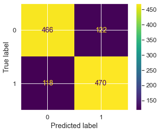

```python
# Confusion matrix on the training data

plot_confusion_matrix(LR_SM_custom, X_train, Y_train)
```

So, True Positives are coming here is 470, that means 470 times our model has predicted correctly on train data, that means it has predicted 1 as 1, and only 118 times it has predicted incorrectly.

Similarly, True Negatives are 466 that means 466 times it has predicted 0 as 0 and only 122 times, the prediction was incorrect.

### Model Performance on Test Data -

```
<sklearn.metrics._plot.confusion_matrix.ConfusionMatrixDisplay at 0x2400d1dba00>
```

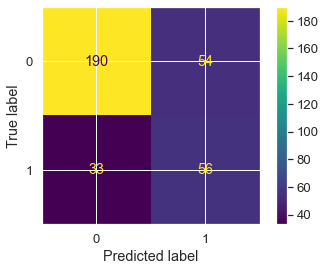

```python
# Confusion Matrix - Test data

plot_confusion_matrix(LR_SM_custom, X_test, Y_test)
```

So, in test data, True Positives are coming here is 56, that means 56 times our model has predicted correctly, that means it has predicted 1 as 1, and other 33 times it has predicted incorrectly.

Similarly, True Negatives are 190 that means 190 times it has predicted 0 as 0 and other 54 times, the prediction was incorrect.

#### So, We still cannot say that this model is best, because it is not performing very well on test data with the selected parameters.

```python
# Predicting Probabilities on train data

probs_train = LR_SM_custom.predict_proba(X_train)
```

```python
# keep probabilities for the positive outcome only

probs_train = probs_train[:, 1]
```

```python
# Calculate Area Under Curve

AUC = roc_auc_score(Y_train, probs_train)

print('AUC: %.3f' % AUC)
```

```
AUC: 0.863
```

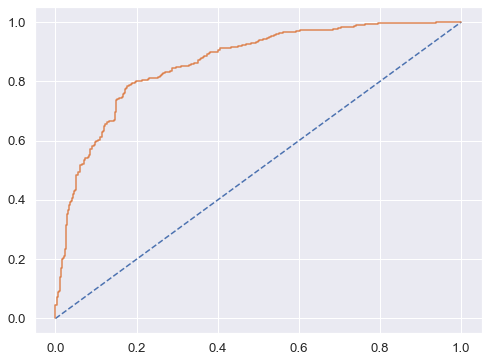

```python
# Calculate ROC curve

train_fpr, train_tpr, train_thresholds = roc_curve(Y_train, probs_train)
plt.rcParams["figure.figsize"] = (8,6)
plt.plot([0, 1], [0, 1], linestyle='--')


# plot the roc curve for the model
plt.plot(train_fpr, train_tpr);
```

```python
# Predicting Probabilities on test data

probs_test = LR_SM_custom.predict_proba(X_test)
```

```python
# keep probabilities for the positive outcome only

probs_test = probs_test[:, 1]
```

```python
# Calculate Area Under Curve

auc_test = roc_auc_score(Y_test, probs_test)

print('AUC: %.3f' % auc_test)
```

```
AUC: 0.792
```

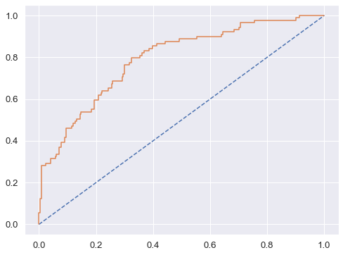

```python
# Calculate ROC curve

test_fpr, test_tpr, test_thresholds = roc_curve(Y_test, probs_test)
plt.rcParams["figure.figsize"] = (8,6)
plt.plot([0, 1], [0, 1], linestyle='--')


# plot the roc curve for the model
plt.plot(test_fpr, test_tpr);
```

So in the above model, the AUC - ROC value for train data is 86% and for test is 79%, this shows that the model is performing good in comparison with the other Logistic Models, but it is still not the best model since the True Positive value is very less.

Also, the confusion matrix and classification report of the 'LR_SM_custom' Logistic Regression Model is giving the above average results.

### Using GridSearchCV for Logistic Regression :-

```python
grid = {'penalty':['l2','none'], 'solver':['sag','lbfgs','saga'], 'tol':[0.0001,0.00001]}

LR_grid = LogisticRegression()
```

```python
grid_search = GridSearchCV(estimator=LR_grid, param_grid = grid, cv=3, n_jobs=-1, scoring='f1')

grid_search.fit(X_train, Y_train)
```

```
GridSearchCV(cv=3, estimator=LogisticRegression(), n_jobs=-1,
             param_grid={'penalty': ['l2', 'none'],
                         'solver': ['sag', 'lbfgs', 'saga'],
                         'tol': [0.0001, 1e-05]},
             scoring='f1')
```

```python
print('Best Parameters from GridSearch:',grid_search.best_params_)

print('\nBest estimator from GridSearch:',grid_search.best_estimator_)
```

```
Best Parameters from GridSearch: {'penalty': 'none', 'solver': 'sag', 'tol': 0.0001}

Best estimator from GridSearch: LogisticRegression(penalty='none', solver='sag')
```

```python
best_LR_model = grid_search.best_estimator_
```

```python
# Prediction - on Train data

train_grid_predict = best_LR_model.predict(X_train)

# Prediction - on Test data

test_grid_predict = best_LR_model.predict(X_test)
```

```python
# Predicting Probabilities - on Test data

test_grid_predict_prob = best_LR_model.predict_proba(X_test)

pd.DataFrame(test_grid_predict_prob).head()
```

|  | 0 | 1 |
| --- | --- | --- |
| 0 | 0.52 | 0.48 |
| 1 | 0.18 | 0.82 |
| 2 | 0.99 | 0.01 |
| 3 | 0.58 | 0.42 |
| 4 | 0.27 | 0.73 |

```
<sklearn.metrics._plot.confusion_matrix.ConfusionMatrixDisplay at 0x2400d2e83d0>
```

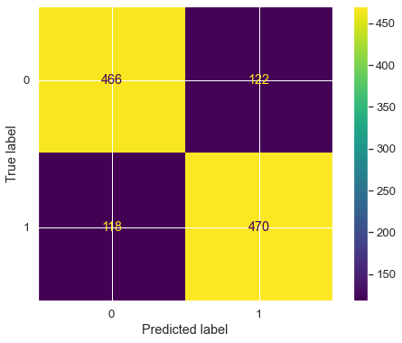

```python
# Confusion Matrix - Train data

plot_confusion_matrix(best_LR_model, X_train, Y_train)
```

```python
# Classification Report - Train data

print(classification_report(Y_train, train_grid_predict))
```

```
              precision    recall  f1-score   support

           0       0.80      0.79      0.80       588
           1       0.79      0.80      0.80       588

    accuracy                           0.80      1176
   macro avg       0.80      0.80      0.80      1176
weighted avg       0.80      0.80      0.80      1176
```

```
<sklearn.metrics._plot.confusion_matrix.ConfusionMatrixDisplay at 0x2400d46e5e0>
```

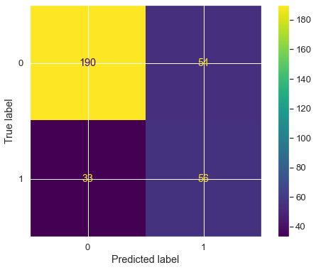

```python
# Confusion Matrix - Test data

plot_confusion_matrix(best_LR_model, X_test, Y_test)
```

```python
# Classification Report - Test data

print(classification_report(Y_test, test_grid_predict))
```

```
              precision    recall  f1-score   support

           0       0.85      0.78      0.81       244
           1       0.51      0.63      0.56        89

    accuracy                           0.74       333
   macro avg       0.68      0.70      0.69       333
weighted avg       0.76      0.74      0.75       333
```

There is no change in the recall values and other matrices as well after using GridSearchCV.

This might not be the best model. We will check other models as well.

### Linear Discriminant Analysis (LDA) :-

```python
# Calling the LDA Classifier

clf = LinearDiscriminantAnalysis()
```

```python
LDA_model = clf.fit(X_train, Y_train)

LDA_model
```

```
LinearDiscriminantAnalysis()
```

```python
# Prediction on Train Data

pred_class_train = LDA_model.predict(X_train)
```

```python
# Prediction on Test Data

pred_class_test = LDA_model.predict(X_test)
```

### Classification Report of Test and Train Data -

```python
print('Classification Report of the training data:\n\n',metrics.classification_report(Y_train, pred_class_train),'\n')
print('Classification Report of the test data:\n\n',metrics.classification_report(Y_test, pred_class_test),'\n')
```

```
Classification Report of the training data:

               precision    recall  f1-score   support

           0       0.80      0.77      0.78       588
           1       0.78      0.80      0.79       588

    accuracy                           0.79      1176
   macro avg       0.79      0.79      0.79      1176
weighted avg       0.79      0.79      0.79      1176


Classification Report of the test data:

               precision    recall  f1-score   support

           0       0.86      0.77      0.81       244
           1       0.50      0.65      0.57        89

    accuracy                           0.74       333
   macro avg       0.68      0.71      0.69       333
weighted avg       0.76      0.74      0.75       333
```

```python
# Training Data Probability Prediction
pred_prob_train = LDA_model.predict_proba(X_train)

# Test Data Probability Prediction
pred_prob_test = LDA_model.predict_proba(X_test)
```

### Confusion Matrix -

```
<sklearn.metrics._plot.confusion_matrix.ConfusionMatrixDisplay at 0x2400d475730>
```

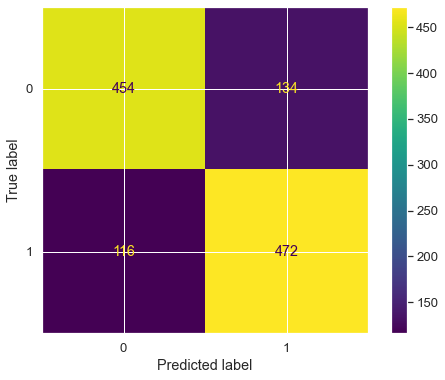

```python
plot_confusion_matrix(LDA_model, X_train, Y_train)
```

```
<sklearn.metrics._plot.confusion_matrix.ConfusionMatrixDisplay at 0x2400d4f2a90>
```

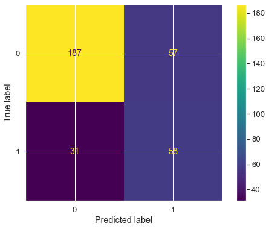

```python
plot_confusion_matrix(LDA_model, X_test, Y_test)
```

### AUC ROC Curve for Train and Test Data -

```
AUC for the Training Data: 0.862
AUC for the Test Data: 0.793
```

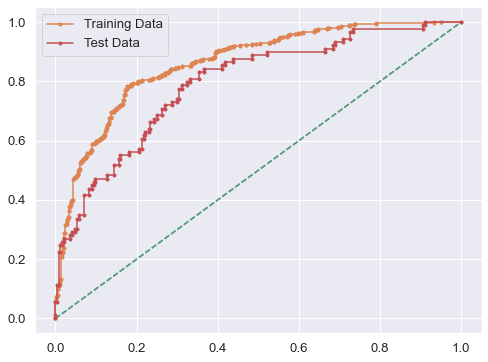

```python
# AUC and ROC for the training data

# calculate AUC
auc_score_train = metrics.roc_auc_score(Y_train, pred_prob_train[:,1])
print('AUC for the Training Data: %.3f' % auc_score_train)

#  calculate roc curve
fpr, tpr, thresholds = metrics.roc_curve(Y_train, pred_prob_train[:,1])
plt.plot([0, 1], [0, 1], linestyle='--')
# plot the roc curve for the model
plt.plot(fpr, tpr, marker='.',label = 'Training Data')


# AUC and ROC for the test data

# calculate AUC
auc_score_test = metrics.roc_auc_score(Y_test, pred_prob_test[:,1])
print('AUC for the Test Data: %.3f' % auc_score_test)

#  calculate roc curve
fpr, tpr, thresholds = metrics.roc_curve(Y_test,pred_prob_test[:,1])
plt.plot([0, 1], [0, 1], linestyle='--')
# plot the roc curve for the model
plt.plot(fpr, tpr, marker='.',label='Test Data')
# show the plot
plt.legend(loc='best')
plt.show()
```

### KNN Model (k-nearest neighbors)

We will be building KNN model (with default values) on re-sampled train sets.

- with default n_neighbors (k) = 5

```python
# Importing KNeighboursClassifier

KNN_model = KNeighborsClassifier()

KNN_model.fit(X_train, Y_train)
```

```
KNeighborsClassifier()
```

```python
# Predicting the model on Train set and check the model score

predicted_labels_train = KNN_model.predict(X_train)

KNN_model_score_train = KNN_model.score(X_train, Y_train)
```

```python
predicted_labels_test = KNN_model.predict(X_test)

KNN_model_score_test = KNN_model.score(X_test, Y_test)
```

```python
KNN_model_score_train
```

```
0.9880952380952381
```

```python
KNN_model_score_test
```

```
0.9039039039039038
```

Accuracy is quite good. Let see the other metrics.

### Classification Report and Confusion Matrix :-

```
Classification Report

              precision    recall  f1-score   support

           0       0.99      0.98      0.99       588
           1       0.98      0.99      0.99       588

    accuracy                           0.99      1176
   macro avg       0.99      0.99      0.99      1176
weighted avg       0.99      0.99      0.99      1176
```

```
<sklearn.metrics._plot.confusion_matrix.ConfusionMatrixDisplay at 0x2400d659ac0>
```

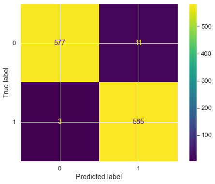

```python
# For train data

print('Classification Report\n')

print(metrics.classification_report(Y_train, predicted_labels_train))

plot_confusion_matrix(KNN_model, X_train, Y_train)
```

```
Classification Report

              precision    recall  f1-score   support

           0       0.98      0.89      0.93       244
           1       0.76      0.94      0.84        89

    accuracy                           0.90       333
   macro avg       0.87      0.92      0.89       333
weighted avg       0.92      0.90      0.91       333
```

```
<sklearn.metrics._plot.confusion_matrix.ConfusionMatrixDisplay at 0x2400d5b23a0>
```

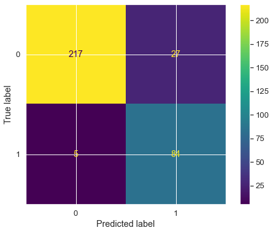

```python
# For test data

print('Classification Report\n')

print(metrics.classification_report(Y_test, predicted_labels_test))

plot_confusion_matrix(KNN_model, X_test, Y_test)
```

Recall Value is much better than the logistic Regression Model and Linear Regression Model.

### AUC ROC Curve :-

```
Area Under Curve: 1.000
```

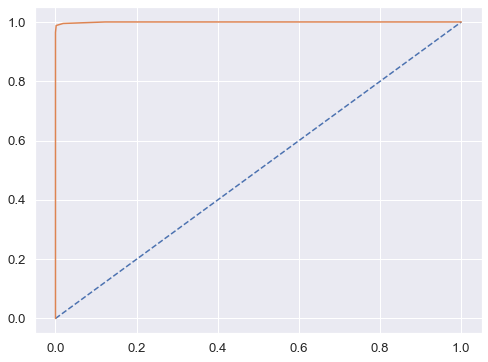

```python
# AUC ROC Curve on Train data

probs_train = KNN_model.predict_proba(X_train)

probs_train = probs_train[:, 1]

auc_for_train = roc_auc_score(Y_train,probs_train)


print("Area Under Curve: %.3f " % auc_for_train)
train_fpr ,train_tpr, train_thresholds= roc_curve(Y_train, probs_train)
plt.plot([0,1],[0,1],linestyle='--')
plt.plot(train_fpr,train_tpr);
```

Since, the AUC = 100% , which is too good and it means that the KNN based classifier's performance on train data is better for the model at distinguishing between the positive and negative classes. let us calculate the performance on test data as well.

```
Area Under Curve: 0.970
```

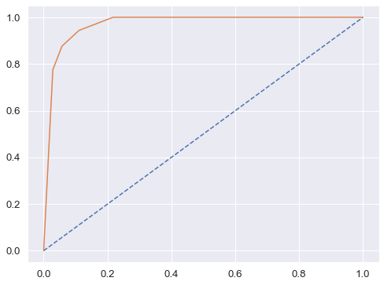

```python
# AUC ROC Curve on Test data

probs_test = KNN_model.predict_proba(X_test)

probs_test = probs_test[:, 1]

auc_for_test = roc_auc_score(Y_test, probs_test)


print("Area Under Curve: %.3f " % auc_for_test)
test_fpr ,test_tpr, test_thresholds= roc_curve(Y_test, probs_test)
plt.plot([0,1],[0,1],linestyle='--')
plt.plot(test_fpr,test_tpr);
```

AUC ROC values are very good on test data as well.

### Naive Bayes Model

```python
# Fit the model into training data

NB_model = GaussianNB()

NB_model.fit(X_train, Y_train)
```

```
GaussianNB()
```

### Let see the performance of our model with training data :-

```python
NB_train_predict = NB_model.predict(X_train)


print("Model Accuracy on Train Data: {0:.2f}".format(metrics.accuracy_score(Y_train, NB_train_predict)))
```

```
Model Accuracy on Train Data: 0.71
```

### Let see the performance of our model with testing data :-

```python
NB_test_predict = NB_model.predict(X_test)


print("Model Accuracy on Test Data: {0:.2f}".format(metrics.accuracy_score(Y_test, NB_test_predict)))
```

```
Model Accuracy on Test Data: 0.64
```

### Classification Report and Confusion Matrix of Train and Test Data :-

```
Classification Report for Train Data:

              precision    recall  f1-score   support

           0       0.74      0.65      0.69       588
           1       0.69      0.78      0.73       588

    accuracy                           0.71      1176
   macro avg       0.72      0.71      0.71      1176
weighted avg       0.72      0.71      0.71      1176
```

```
<sklearn.metrics._plot.confusion_matrix.ConfusionMatrixDisplay at 0x2400d80f9a0>
```

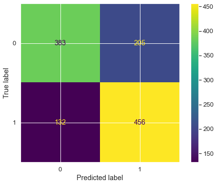

```python
print('Classification Report for Train Data:\n')

print(metrics.classification_report(Y_train, NB_train_predict))

plot_confusion_matrix(NB_model, X_train, Y_train)
```

```
Classification Report for Test Data:

              precision    recall  f1-score   support

           0       0.85      0.62      0.72       244
           1       0.40      0.71      0.51        89

    accuracy                           0.64       333
   macro avg       0.63      0.66      0.62       333
weighted avg       0.73      0.64      0.66       333
```

```
<sklearn.metrics._plot.confusion_matrix.ConfusionMatrixDisplay at 0x2400d8e9ca0>
```

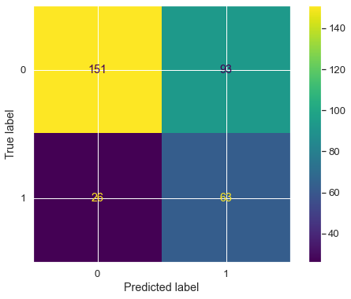

```python
print('Classification Report for Test Data:\n')

print(metrics.classification_report(Y_test, NB_test_predict))

plot_confusion_matrix(NB_model, X_test, Y_test)
```

### Random Forest Classifier -

```python
# Calling the Random Forest Classifier with hyper-parameters

rfcl = RandomForestClassifier(n_estimators=301,
                              oob_score = True,
                              max_depth = 10,
                              max_features = 5,
                              min_samples_leaf = 50,
                              min_samples_split=110)

rfcl = rfcl.fit(X_train, Y_train)
```

#### Hyper-parameters for the classifier :

- n_estimators = number of trees, that we want to build within the RandomForestClassifier.
- Out of bag (OOB) score is a way of validating the Random forest model. It is computed as the number of correctly predicted rows from the out of bag sample.
- max_features will be used to select randomly features from the available number of features.

```python
rfcl
```

```
RandomForestClassifier(max_depth=10, max_features=5, min_samples_leaf=50,
                       min_samples_split=110, n_estimators=301, oob_score=True)
```

### OOB Score (Out of Bag) and Error Rate for Random Forest Classifier -

The OOB score is computed as the number of correctly predicted rows from the out of bag sample.

```python
rfcl.oob_score_
```

```
0.8163265306122449
```

```python
#Checking the error rate in %:

print('Error_rate(in %) :', 1- (rfcl.oob_score_)) #OOB Error is the number of wrongly classifying the OOB Sample.
```

```
Error_rate(in %) : 0.18367346938775508
```

For the above specified grid parameters, we got the Random Forest Model with OOB score around 81% and error rate around 19%, which shows the model is good to go for further evaluation.

### Getting the Feature Importances :-

Feature Importance refers to techniques that calculate a score for all the input features for a given model — the scores simply represent the “importance” of each feature. A higher score means that the specific feature will have a larger effect on the model that is being used to predict a certain variable.

```python
print(pd.DataFrame(rfcl.feature_importances_,
                   columns = ["Imp"],
                   index = X_train.columns).sort_values('Imp',ascending=False))
```

```
                             Imp
YA_view_on_CP               0.21
TL_rec_on_OS_checkin        0.17
Following_CP_Yes            0.16
DA_mins_spend_on_CP         0.10
Adult_flag_1                0.10
YA_comment_on_CP            0.06
TL_done_on_OS_checkin       0.05
Week_since_last_OS_checkin  0.05
YA_OS_checkin               0.04
Members_in_fam              0.03
Travelling_network_rating_4 0.02
Travelling_network_rating_3 0.00
Working_flag_Yes            0.00
Pref_loc_type_Big_Cities    0.00
Pref_loc_type_Other         0.00
Travelling_network_rating_2 0.00
Pref_device_Mobile          0.00
```

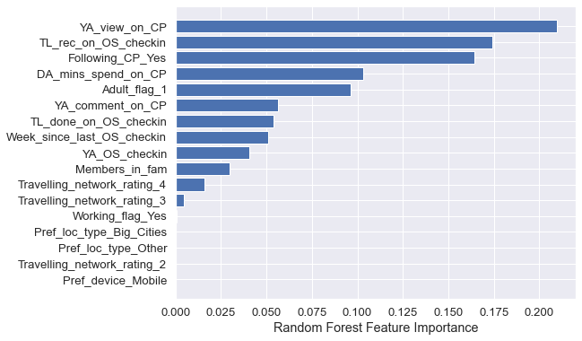

```python
# let us Visualize this in a sorted manner :

sorted_idx = rfcl.feature_importances_.argsort()
plt.barh(X_train.columns[sorted_idx], rfcl.feature_importances_[sorted_idx])
plt.xlabel("Random Forest Feature Importance")
```

### Model Performance on Train and Test data -

```python
# Prediction on Train Data

rfcl_train_predict = rfcl.predict(X_train)

print("Model Accuracy on Train Data: {0:.2f}".format(metrics.accuracy_score(Y_train, rfcl_train_predict)))
```

```
Model Accuracy on Train Data: 0.85
```

```python
# Prediction on Test Data

rfcl_test_predict = rfcl.predict(X_test)

print("Model Accuracy on Test Data: {0:.2f}".format(metrics.accuracy_score(Y_test, rfcl_test_predict)))
```

```
Model Accuracy on Test Data: 0.79
```

### Classification Report and Confusion Matrix -

```
Classification Report for Train Data:

              precision    recall  f1-score   support

           0       0.82      0.88      0.85       588
           1       0.87      0.81      0.84       588

    accuracy                           0.85      1176
   macro avg       0.85      0.85      0.85      1176
weighted avg       0.85      0.85      0.85      1176
```

```
<sklearn.metrics._plot.confusion_matrix.ConfusionMatrixDisplay at 0x2400db05850>
```

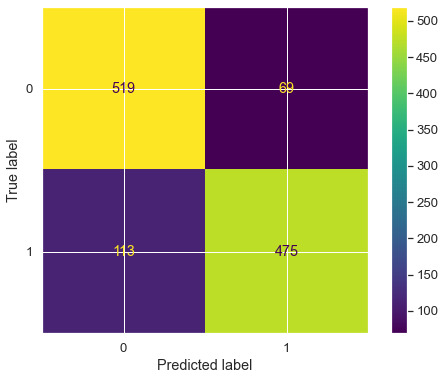

```python
print('Classification Report for Train Data:\n')

print(metrics.classification_report(Y_train, rfcl_train_predict))

plot_confusion_matrix(rfcl, X_train, Y_train)
```

```
Classification Report for Test Data:

              precision    recall  f1-score   support

           0       0.90      0.81      0.85       244
           1       0.59      0.74      0.66        89

    accuracy                           0.79       333
   macro avg       0.74      0.78      0.75       333
weighted avg       0.81      0.79      0.80       333
```

```
<sklearn.metrics._plot.confusion_matrix.ConfusionMatrixDisplay at 0x2400dbd2f70>
```

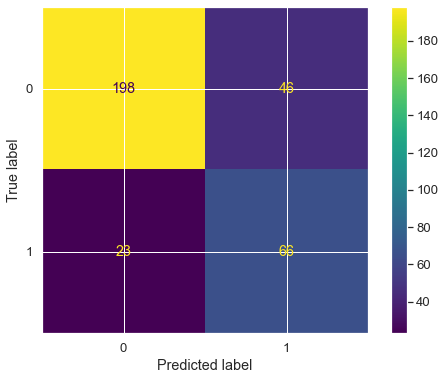

```python
print('Classification Report for Test Data:\n')

print(metrics.classification_report(Y_test, rfcl_test_predict))

plot_confusion_matrix(rfcl, X_test, Y_test)
```

### Now let us use Ensemble Techniques : Bagging, Ada Boosting, GradientBoost :

### Bagging - Random Forest (with Bagging as Ensemble Method) -

```python
# let us first look by use Bagging

# We will be using random forest as base_estimator

bgcl = BaggingClassifier(base_estimator=rfcl, n_estimators=10, random_state=22)


# Fit the model on training data
bgcl = bgcl.fit(X_train, Y_train)
```

### Model Performance -

```python
# Predict on Train Data

bgcl_train_predict = bgcl.predict(X_train)
```

```python
# Predict on Test Data

bgcl_test_predict = bgcl.predict(X_test)
```

### Classification Report and Confusion Matrix -

```
Classification Report for Train Data:

              precision    recall  f1-score   support

           0       0.80      0.85      0.82       588
           1       0.84      0.79      0.81       588

    accuracy                           0.82      1176
   macro avg       0.82      0.82      0.82      1176
weighted avg       0.82      0.82      0.82      1176
```

```
<sklearn.metrics._plot.confusion_matrix.ConfusionMatrixDisplay at 0x2400dc52dc0>
```

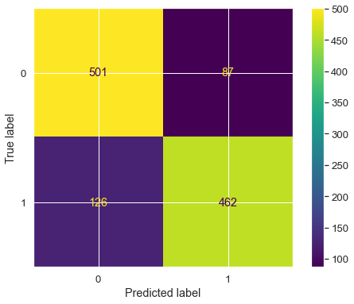

```python
# For Train Data

print('Classification Report for Train Data:\n')

print(metrics.classification_report(Y_train, bgcl_train_predict))

plot_confusion_matrix(bgcl, X_train, Y_train)
```

```
Classification Report for test Data:

              precision    recall  f1-score   support

           0       0.90      0.80      0.85       244
           1       0.58      0.75      0.65        89

    accuracy                           0.79       333
   macro avg       0.74      0.78      0.75       333
weighted avg       0.81      0.79      0.79       333
```

```
<sklearn.metrics._plot.confusion_matrix.ConfusionMatrixDisplay at 0x2400de67250>
```

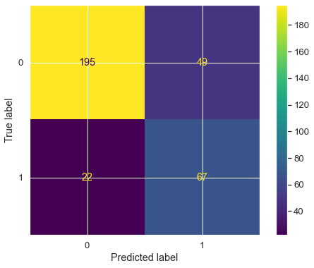

```python
# For test Data

print('Classification Report for test Data:\n')

print(metrics.classification_report(Y_test, bgcl_test_predict))

plot_confusion_matrix(bgcl, X_test, Y_test)
```

By using the Bagging, we can observe that the model performance on test data has not improved too much. Now we will use Ada-Boosting and then compare the model once again.

### Ada Boosting -

```python
# Calling the ada boosting classifier

abcl = AdaBoostClassifier(base_estimator=rfcl, n_estimators=200, random_state=1)

# Fit the model on train data
abcl = abcl.fit(X_train, Y_train)
```

### Model Evaluation -

```python
# Prediction on Train Data

abcl_train_predict = abcl.predict(X_train)
```

```python
# Prediction on Test Data

abcl_test_predict = abcl.predict(X_test)
```

### Classification Report and Confusion Matrix -

```
Classification Report for Train Data:

              precision    recall  f1-score   support

           0       0.98      0.99      0.99       588
           1       0.99      0.98      0.99       588

    accuracy                           0.99      1176
   macro avg       0.99      0.99      0.99      1176
weighted avg       0.99      0.99      0.99      1176
```

```
<sklearn.metrics._plot.confusion_matrix.ConfusionMatrixDisplay at 0x2400d899730>
```

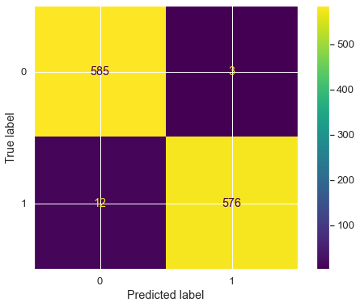

```python
# For Train Data

print('Classification Report for Train Data:\n')

print(metrics.classification_report(Y_train, abcl_train_predict))

plot_confusion_matrix(abcl, X_train, Y_train)
```

```
Classification Report for test Data:

              precision    recall  f1-score   support

           0       0.94      0.95      0.94       244
           1       0.85      0.83      0.84        89

    accuracy                           0.92       333
   macro avg       0.89      0.89      0.89       333
weighted avg       0.92      0.92      0.92       333
```

```
<sklearn.metrics._plot.confusion_matrix.ConfusionMatrixDisplay at 0x2400dfdc0d0>
```

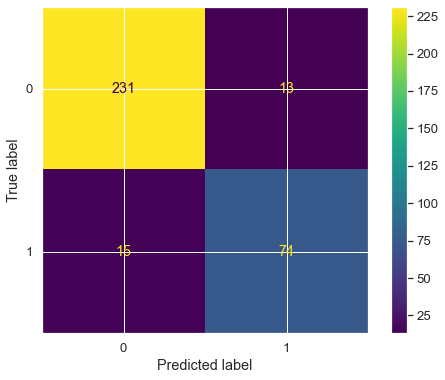

```python
# For test Data

print('Classification Report for test Data:\n')

print(metrics.classification_report(Y_test, abcl_test_predict))

plot_confusion_matrix(abcl, X_test, Y_test)
```

### Gradient Boost -

- Gradient boosting algorithm is one of the most powerful algorithms in the field of machine learning. As we know that the errors in machine learning algorithms are broadly classified into two categories i.e. Bias Error and Variance Error. As gradient boosting is one of the boosting algorithms it is used to minimize bias error of the model.
- Unlike, Ada-boosting algorithm, the base estimator in the gradient boosting algorithm cannot be mentioned by us. The base estimator for the Gradient Boost algorithm is fixed and i.e. Decision Stump. Like, Ada-Boost, we can tune the n_estimator of the gradient boosting algorithm. However, if we do not mention the value of n_estimator, the default value of n_estimator for this algorithm is 100.

```python
# Calling the Gradient Boost Classifier with it's own default base estimator and n_estimators =100 :

gbcl = GradientBoostingClassifier(n_estimators = 251, random_state=11)

# Fit the model on train data
gbcl = gbcl.fit(X_train, Y_train)
```

### Model Evaluation -

```python
# Score on train and test set

print('Gradient boost score on train set:',gbcl.score(X_train, Y_train))
print('Gradient boost score on train set:',gbcl.score(X_test, Y_test))
```

```
Gradient boost score on train set: 0.9991496598639455
Gradient boost score on train set: 0.948948948948949
```

```python
# Prediction on Train and Test Data

gbcl_train_predict = gbcl.predict(X_train)
gbcl_test_predict = gbcl.predict(X_test)
```

### Classification Report and Confusion Matrix -

```
Classification Report for train Data:

              precision    recall  f1-score   support

           0       1.00      1.00      1.00       588
           1       1.00      1.00      1.00       588

    accuracy                           1.00      1176
   macro avg       1.00      1.00      1.00      1176
weighted avg       1.00      1.00      1.00      1176
```

```
<sklearn.metrics._plot.confusion_matrix.ConfusionMatrixDisplay at 0x2400e01f070>
```

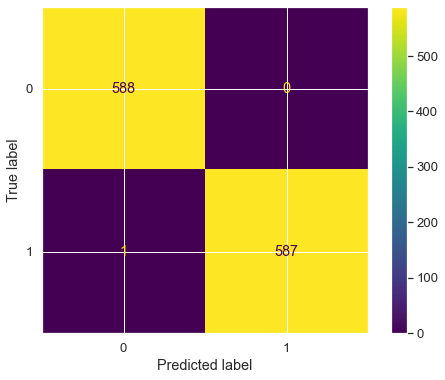

```python
# For Train Data

print('Classification Report for train Data:\n')

print(metrics.classification_report(Y_train, gbcl_train_predict))

plot_confusion_matrix(gbcl, X_train, Y_train)
```

```
Classification Report for test Data:

              precision    recall  f1-score   support

           0       0.95      0.98      0.97       244
           1       0.94      0.87      0.90        89

    accuracy                           0.95       333
   macro avg       0.95      0.92      0.93       333
weighted avg       0.95      0.95      0.95       333
```

```
<sklearn.metrics._plot.confusion_matrix.ConfusionMatrixDisplay at 0x2400dfdc0a0>
```

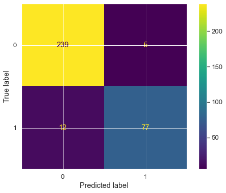

```python
# For test Data

print('Classification Report for test Data:\n')

print(metrics.classification_report(Y_test, gbcl_test_predict))

plot_confusion_matrix(gbcl, X_test, Y_test)
```

- Gradient Boosting Algorithm is performing too good on test data, as we can see that the accuracy is 95% with precision 94% and recall 87% for the minority class (1).
- The value of True Positives is 77, that means the model is able to predict correctly 77 times out of 89, and only 12 times it is predicting incorrectly.
- This is a great model, and much better than the other previous models like Logistic Regression, LDA, KNN, Naive Bayes and Random Forest.

### MODEL BUILDING APPROACH : FOR MOBILE USERS (data_mobile) -

### Train-Test Split - In 70:30 Ratio

```python
#Now, let us separate dependent and independent variables

x = data_mobile.drop('Taken_product_Yes', axis=1)

y = data_mobile[['Taken_product_Yes']]
```

```python
# Split the data into test and train sets in 70:30 ratio

x_train, x_test, y_train, y_test = train_test_split(x, y, test_size = 0.30, random_state = 11)
```

```python
print('Shape of x_train:',x_train.shape)

x_train.head().T
```

```
Shape of x_train: (5949, 20)
```

|  | 11745 | 10915 | 5180 | 5634 | 3516 |
| --- | --- | --- | --- | --- | --- |
| YA_view_on_CP | 308.00 | 351.00 | 346.00 | 202.00 | 204.00 |
| TL_done_on_OS_checkin | 46314.00 | 32589.00 | 15080.00 | 13698.00 | 29051.00 |
| YA_OS_checkin | 2.00 | 9.00 | 1.00 | 17.00 | 1.00 |
| Members_in_fam | 4.00 | 3.00 | 4.00 | 4.00 | 1.00 |
| YA_comment_on_CP | 68.00 | 97.00 | 52.00 | 76.00 | 97.00 |
| TL_rec_on_OS_checkin | 2864.00 | 10813.00 | 13880.20 | 2358.00 | 4401.00 |
| Week_since_last_OS_checkin | 2.00 | 6.00 | 7.00 | 3.00 | 1.00 |
| DA_mins_spend_on_CP | 9.00 | 22.00 | 26.00 | 6.00 | 12.00 |
| Pref_device_Mobile | 1.00 | 1.00 | 1.00 | 1.00 | 1.00 |
| Pref_loc_type_Big_Cities | 0.00 | 1.00 | 0.00 | 0.00 | 0.00 |
| Pref_loc_type_Entertainment | 0.00 | 0.00 | 0.00 | 0.00 | 1.00 |
| Pref_loc_type_Financial | 0.00 | 0.00 | 0.00 | 0.00 | 0.00 |
| Pref_loc_type_Medical | 0.00 | 0.00 | 1.00 | 1.00 | 0.00 |
| Pref_loc_type_Other | 0.00 | 0.00 | 0.00 | 0.00 | 0.00 |
| Following_CP_Yes | 0.00 | 1.00 | 0.00 | 0.00 | 0.00 |
| Working_flag_Yes | 0.00 | 0.00 | 0.00 | 0.00 | 0.00 |
| Travelling_network_rating_2 | 0.00 | 0.00 | 0.00 | 0.00 | 1.00 |
| Travelling_network_rating_3 | 0.00 | 1.00 | 0.00 | 1.00 | 0.00 |
| Travelling_network_rating_4 | 1.00 | 0.00 | 1.00 | 0.00 | 0.00 |
| Adult_flag_1 | 0.00 | 1.00 | 1.00 | 1.00 | 1.00 |

### Normalization of Train Data -

```python
# Normalization of x_train

scaler = MinMaxScaler()

x_train = pd.DataFrame(scaler.fit_transform(x_train),columns = x_train.columns)
```

```python
print('Shape of y_train:',x_train.shape)

x_train.head().T
```

[output not shown]

|  | 0 | 1 | 2 | 3 | 4 |
| --- | --- | --- | --- | --- | --- |
| YA_view_on_CP | 0.59 | 0.82 | 0.80 | 0.00 | 0.01 |
| TL_done_on_OS_checkin | 0.97 | 0.62 | 0.17 | 0.13 | 0.53 |
| YA_OS_checkin | 0.05 | 0.36 | 0.00 | 0.73 | 0.00 |
| Members_in_fam | 1.00 | 0.67 | 1.00 | 1.00 | 0.00 |
| YA_comment_on_CP | 0.37 | 0.88 | 0.09 | 0.51 | 0.88 |
| TL_rec_on_OS_checkin | 0.04 | 0.73 | 1.00 | 0.00 | 0.18 |
| Week_since_last_OS_checkin | 0.17 | 0.83 | 1.00 | 0.33 | 0.00 |
| DA_mins_spend_on_CP | 0.19 | 0.81 | 1.00 | 0.05 | 0.33 |
| Pref_device_Mobile | 0.00 | 0.00 | 0.00 | 0.00 | 0.00 |
| Pref_loc_type_Big_Cities | 0.00 | 1.00 | 0.00 | 0.00 | 0.00 |
| Pref_loc_type_Entertainment | 0.00 | 0.00 | 0.00 | 0.00 | 1.00 |
| Pref_loc_type_Financial | 0.00 | 0.00 | 0.00 | 0.00 | 0.00 |
| Pref_loc_type_Medical | 0.00 | 0.00 | 1.00 | 1.00 | 0.00 |
| Pref_loc_type_Other | 0.00 | 0.00 | 0.00 | 0.00 | 0.00 |
| Following_CP_Yes | 0.00 | 1.00 | 0.00 | 0.00 | 0.00 |
| Working_flag_Yes | 0.00 | 0.00 | 0.00 | 0.00 | 0.00 |
| Travelling_network_rating_2 | 0.00 | 0.00 | 0.00 | 0.00 | 1.00 |
| Travelling_network_rating_3 | 0.00 | 1.00 | 0.00 | 1.00 | 0.00 |
| Travelling_network_rating_4 | 1.00 | 0.00 | 1.00 | 0.00 | 0.00 |
| Adult_flag_1 | 0.00 | 1.00 | 1.00 | 1.00 | 1.00 |

### Normalization of Test Data -

```python
print('Shape of x_test:',x_test.shape)

print('\nBefore Normalization:\n')

x_test.head().T
```

```
Shape of x_test: (2550, 20)

Before Normalization:
```

|  | 8592 | 6243 | 5650 | 4869 | 8051 |
| --- | --- | --- | --- | --- | --- |
| YA_view_on_CP | 310.00 | 257.00 | 294.00 | 310.00 | 383.00 |
| TL_done_on_OS_checkin | 21389.00 | 12261.00 | 27755.00 | 17855.00 | 47505.80 |
| YA_OS_checkin | 7.00 | 5.00 | 1.00 | 1.00 | 2.00 |
| Members_in_fam | 4.00 | 3.00 | 3.00 | 4.00 | 2.00 |
| YA_comment_on_CP | 96.00 | 47.00 | 91.00 | 76.00 | 50.00 |
| TL_rec_on_OS_checkin | 13880.20 | 2856.00 | 6530.00 | 6855.00 | 13880.20 |
| Week_since_last_OS_checkin | 1.00 | 1.00 | 1.00 | 2.00 | 6.00 |
| DA_mins_spend_on_CP | 21.00 | 5.00 | 16.00 | 13.00 | 22.00 |
| Pref_device_Mobile | 1.00 | 1.00 | 1.00 | 1.00 | 1.00 |
| Pref_loc_type_Big_Cities | 0.00 | 1.00 | 0.00 | 0.00 | 0.00 |
| Pref_loc_type_Entertainment | 0.00 | 0.00 | 0.00 | 0.00 | 0.00 |
| Pref_loc_type_Financial | 0.00 | 0.00 | 1.00 | 0.00 | 0.00 |
| Pref_loc_type_Medical | 0.00 | 0.00 | 0.00 | 0.00 | 0.00 |
| Pref_loc_type_Other | 0.00 | 0.00 | 0.00 | 1.00 | 0.00 |
| Following_CP_Yes | 0.00 | 1.00 | 1.00 | 1.00 | 0.00 |
| Working_flag_Yes | 0.00 | 0.00 | 0.00 | 0.00 | 0.00 |
| Travelling_network_rating_2 | 1.00 | 1.00 | 0.00 | 0.00 | 0.00 |
| Travelling_network_rating_3 | 0.00 | 0.00 | 0.00 | 0.00 | 1.00 |
| Travelling_network_rating_4 | 0.00 | 0.00 | 1.00 | 0.00 | 0.00 |
| Adult_flag_1 | 0.00 | 0.00 | 1.00 | 0.00 | 1.00 |

```python
# Normalization of x_test

x_test = pd.DataFrame(scaler.fit_transform(x_test),columns = x_test.columns)
```

```python
print('After Normalization:\n')
x_test.head().T
```

```
After Normalization:
```

|  | 0 | 1 | 2 | 3 | 4 |
| --- | --- | --- | --- | --- | --- |
| YA_view_on_CP | 0.60 | 0.30 | 0.51 | 0.60 | 1.00 |
| TL_done_on_OS_checkin | 0.33 | 0.10 | 0.49 | 0.24 | 1.00 |
| YA_OS_checkin | 0.27 | 0.18 | 0.00 | 0.00 | 0.05 |
| Members_in_fam | 1.00 | 0.67 | 0.67 | 1.00 | 0.33 |
| YA_comment_on_CP | 0.86 | 0.00 | 0.77 | 0.51 | 0.05 |
| TL_rec_on_OS_checkin | 1.00 | 0.04 | 0.36 | 0.39 | 1.00 |
| Week_since_last_OS_checkin | 0.00 | 0.00 | 0.00 | 0.17 | 0.83 |
| DA_mins_spend_on_CP | 0.76 | 0.00 | 0.52 | 0.38 | 0.81 |
| Pref_device_Mobile | 0.00 | 0.00 | 0.00 | 0.00 | 0.00 |
| Pref_loc_type_Big_Cities | 0.00 | 1.00 | 0.00 | 0.00 | 0.00 |
| Pref_loc_type_Entertainment | 0.00 | 0.00 | 0.00 | 0.00 | 0.00 |
| Pref_loc_type_Financial | 0.00 | 0.00 | 1.00 | 0.00 | 0.00 |
| Pref_loc_type_Medical | 0.00 | 0.00 | 0.00 | 0.00 | 0.00 |
| Pref_loc_type_Other | 0.00 | 0.00 | 0.00 | 1.00 | 0.00 |
| Following_CP_Yes | 0.00 | 1.00 | 1.00 | 1.00 | 0.00 |
| Working_flag_Yes | 0.00 | 0.00 | 0.00 | 0.00 | 0.00 |
| Travelling_network_rating_2 | 1.00 | 1.00 | 0.00 | 0.00 | 0.00 |
| Travelling_network_rating_3 | 0.00 | 0.00 | 0.00 | 0.00 | 1.00 |
| Travelling_network_rating_4 | 0.00 | 0.00 | 1.00 | 0.00 | 0.00 |
| Adult_flag_1 | 0.00 | 0.00 | 1.00 | 0.00 | 1.00 |

```python
data_mobile['Taken_product_Yes'].value_counts()
```

```
0    7221
1    1278
Name: Taken_product_Yes, dtype: int64
```

```python
data_mobile['Taken_product_Yes'].value_counts(normalize = True)
```

```
0   0.85
1   0.15
Name: Taken_product_Yes, dtype: float64
```

```python
data_mobile.shape
```

```
(8499, 21)
```

We can see that, out of 8499 mobile users, only 1278 (around 15%) has taken the product and 7221 (around 85%) has not taken the product.

### Need of applying SMOTE :-

As per our analysis, we got to know that the data is more towards the negative side, like majority of the users have not taken our product.This clearly means that data is in imbalance state.

Standard ML techniques such as Decision Tree and Logistic Regression have a bias towards the majority class, and they tend to ignore the minority class. They tend only to predict the majority class, hence, having major misclassification of the minority class in comparison with the majority class. In more technical words, if we have imbalanced data distribution in our dataset then our model becomes more prone to the case when minority class has negligible or very lesser recall.

So we will be using a over sampling technique called SMOTE to handle imbalanced data.

### Logistic Regression Model (with default values) : On imbalance data

```python
# Let us first now train the data without handling imbalance problem

LR_mob = LogisticRegression()
```

```python
# Now let us fit the model on training data

LR_mob.fit(x_train, y_train)
```

```
LogisticRegression()
```

```python
# Prdecition on training data

y_train_predict = LR_mob.predict(x_train)
```

```python
# Prdecition on testing data

y_test_predict = LR_mob.predict(x_test)
```

```python
# Getting the predicted classes and probs

y_test_predict_prob = LR_mob.predict_proba(x_test)
```

### Model Evaluation - Accuracy, Classification Report -

```python
# Accuracy on training data

LR_mob.score(x_train, y_train)
```

```
0.866700285762313
```

```python
# Classification Report - training data

print(classification_report(y_train, y_train_predict))
```

```
              precision    recall  f1-score   support

           0       0.87      0.99      0.93      5042
           1       0.73      0.20      0.32       907

    accuracy                           0.87      5949
   macro avg       0.80      0.59      0.62      5949
weighted avg       0.85      0.87      0.83      5949
```

```python
# Classification Report - testing data

print(classification_report(y_test, y_test_predict))
```

```
              precision    recall  f1-score   support

           0       0.89      0.98      0.93      2179
           1       0.71      0.27      0.39       371

    accuracy                           0.88      2550
   macro avg       0.80      0.63      0.66      2550
weighted avg       0.86      0.88      0.85      2550
```

We can see that model performs very bad on imbalanced data. The recall value for the minority class (1) is only 27% on test data. Hence now we will apply SMOTE (Oversampling) technique on imbalance data and make it balanced for better performance.

### Applying SMOTE -

Now, we will apply the imbalanced data handling technique, called SMOTE and test it's accuracy and recall results.

```python
SM = SMOTE(random_state = 2)

x_train, y_train = SM.fit_sample(x_train, y_train)
```

```python
print('After OverSampling, the shape of x_train:',x_train.shape)

print('After OverSampling, the shape of y_train:',y_train.shape)
```

```
After OverSampling, the shape of x_train: (10084, 20)
After OverSampling, the shape of y_train: (10084, 1)
```

### Logistic Regression Model (with default values) : On balanced data - After applying SMOTE - Oversampling

Now we will again make the model and check the recall values for majority and minority classes.

```python
LR_mob_SM = LogisticRegression() #named 'LR_mob_SM' where SM represents SMOTE, just to differentiate from previous LR model
```

```python
# Now let us fit the model on train data

LR_mob_SM.fit(x_train, y_train)
```

```
LogisticRegression()
```

```python
# Prdecition - on Train data

y_train_predict_SM = LR_mob_SM.predict(x_train)
```

```python
# Prdecition - on Test data

y_test_predict_SM = LR_mob_SM.predict(x_test)
```

### Model Evaluation - Accuracy and Classification Report -

```python
# Model Evaluation - Accuracy on Train data

LR_mob_SM.score(x_train, y_train)
```

```
0.7259024196747322
```

```python
# Classification Report - Train data

print(classification_report(y_train, y_train_predict_SM))
```

```
              precision    recall  f1-score   support

           0       0.73      0.72      0.72      5042
           1       0.72      0.73      0.73      5042

    accuracy                           0.73     10084
   macro avg       0.73      0.73      0.73     10084
weighted avg       0.73      0.73      0.73     10084
```

```python
# Classification Report - Test data

print(classification_report(y_test, y_test_predict_SM))
```

```
              precision    recall  f1-score   support

           0       0.95      0.72      0.82      2179
           1       0.32      0.78      0.46       371

    accuracy                           0.73      2550
   macro avg       0.64      0.75      0.64      2550
weighted avg       0.86      0.73      0.77      2550
```

Now the difference is clear, that after over-sampling, the accuracy has been reduced, but recall value is now much better than the model for imbalance data.

The accuracy of 73% is acceptable with good recall value for minority class, rather than the high accuracy with bad recall value. But now the precision value for minority class has reduced too much.

So here we will focus more on improving our recall and precision. Now, the recall for the minority class has been increased a lot, and it is very good. But the recall for the majority class has been decreased, this is due the fact that now that there is a balance in both the classes.

### Logistic Regression Model (Customized Values) : On balanced data - After applying SMOTE - Oversampling

As we have build the previous model with it's default values. There might be chances of more better model than this, with some customized parameters for the logistic regression model.

We can improve the model by tuning the hyper-parameters of the model. So here we will use 'GridSearchCV' method to get the best parameters and then we would want to test out in the model again.

```python
# Fit the Logistic Regression model

LR_mob_SM_custom = LogisticRegression(solver='lbfgs', penalty='none', max_iter=100000, n_jobs=2, verbose=True)

LR_mob_SM_custom.fit(x_train, y_train)
```

```
[Parallel(n_jobs=2)]: Using backend LokyBackend with 2 concurrent workers.
[Parallel(n_jobs=2)]: Done   1 out of   1 | elapsed:    3.1s finished
```

```
LogisticRegression(max_iter=100000, n_jobs=2, penalty='none', verbose=True)
```

```python
# Prdecition - on Train data

y_train_predict_SM_custom = LR_mob_SM_custom.predict(x_train)
```

```python
# Prdecition - on Test data

y_test_predict_SM_custom = LR_mob_SM_custom.predict(x_test)
```

### Model Evaluation - Classification Report, Confusion Matrix, AUC ROC -

```python
# Model Evaluation - Accuracy - for Train data

LR_mob_SM_custom.score(x_train, y_train)
```

```
0.7261007536691789
```

```python
# Classification Report - Train data

print(classification_report(y_train, y_train_predict_SM_custom))
```

```
              precision    recall  f1-score   support

           0       0.73      0.72      0.72      5042
           1       0.72      0.73      0.73      5042

    accuracy                           0.73     10084
   macro avg       0.73      0.73      0.73     10084
weighted avg       0.73      0.73      0.73     10084
```

```python
# Classification Report - Test data

print(classification_report(y_test, y_test_predict_SM_custom))
```

```
              precision    recall  f1-score   support

           0       0.95      0.72      0.82      2179
           1       0.32      0.78      0.46       371

    accuracy                           0.73      2550
   macro avg       0.64      0.75      0.64      2550
weighted avg       0.86      0.73      0.77      2550
```

```
<sklearn.metrics._plot.confusion_matrix.ConfusionMatrixDisplay at 0x24010bd0190>
```

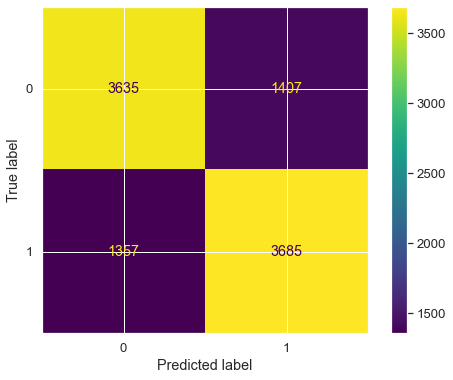

```python
## Confusion matrix - Train data

plot_confusion_matrix(LR_mob_SM, x_train, y_train)
```

```
<sklearn.metrics._plot.confusion_matrix.ConfusionMatrixDisplay at 0x24010bd0fa0>
```

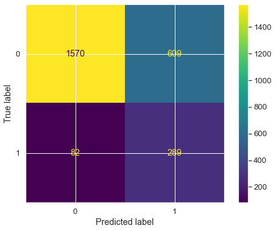

```python
## Confusion matrix - Test data

plot_confusion_matrix(LR_mob_SM, x_test, y_test)
```

This model averagely performing on test data, as out of 371 times, it is predicting 82 times incorrectly.

```python
y_test.value_counts()
```

```
Taken_product_Yes
0                    2179
1                     371
dtype: int64
```

```python
# Predicting Probabilities

probs_for_train = LR_mob_SM.predict_proba(x_train)
probs_for_test = LR_mob_SM.predict_proba(x_test)
```

```
AUC: 0.795
```

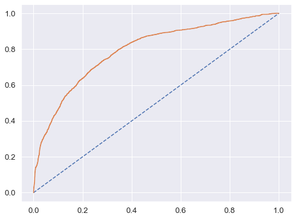

```python
# Keep probabilities for the positive outcome only

probs_for_train = probs_for_train[:, 1]

# Calculate Area Under Curve

auc = roc_auc_score(y_train, probs_for_train)

print('AUC: %.3f' % auc)

# Calculate ROC curve

train_fpr, train_tpr, train_thresholds = roc_curve(y_train, probs_for_train)
plt.rcParams["figure.figsize"] = (8,6)
plt.plot([0, 1], [0, 1], linestyle='--')


# Plot the roc curve for the model
plt.plot(train_fpr, train_tpr);
```

```
AUC: 0.800
```

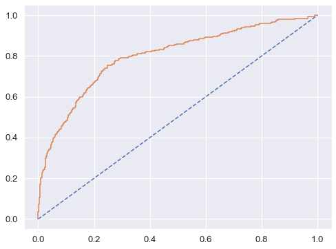

```python
# Keep probabilities for the positive outcome only

probs_for_test = probs_for_test[:, 1]

# Calculate Area Under Curve

auc = roc_auc_score(y_test, probs_for_test)

print('AUC: %.3f' % auc)

# Calculate ROC curve

test_fpr, test_tpr, test_thresholds = roc_curve(y_test, probs_for_test)
plt.rcParams["figure.figsize"] = (8,6)
plt.plot([0, 1], [0, 1], linestyle='--')


# Plot the roc curve for the model
plt.plot(test_fpr, test_tpr);
```

### Using GridSearchCV for Logistic Regression :-

```python
grid = {'penalty':['l2','none'], 'solver':['sag','lbfgs'], 'tol':[0.0001,0.00001]}

LR_mob_grid = LogisticRegression(max_iter=10000, n_jobs=2)

grid_search = GridSearchCV(estimator=LR_mob_grid, param_grid = grid, cv=5, n_jobs=-1, scoring='f1')

grid_search.fit(x_train, y_train)
```

```
GridSearchCV(cv=5, estimator=LogisticRegression(max_iter=10000, n_jobs=2),
             n_jobs=-1,
             param_grid={'penalty': ['l2', 'none'], 'solver': ['sag', 'lbfgs'],
                         'tol': [0.0001, 1e-05]},
             scoring='f1')
```

```python
print('Best Parameters from GridSearch:',grid_search.best_params_)

print('\nBest estimator from GridSearch:',grid_search.best_estimator_)

best_LR_mob_model = grid_search.best_estimator_
```

```
Best Parameters from GridSearch: {'penalty': 'none', 'solver': 'sag', 'tol': 0.0001}

Best estimator from GridSearch: LogisticRegression(max_iter=10000, n_jobs=2, penalty='none', solver='sag')
```

```python
# Prediction - Train data and Test Data

y_train_grid_predict = best_LR_mob_model.predict(x_train)
y_test_grid_predict = best_LR_mob_model.predict(x_test)
```

```python
# Getting the probabilities - Test data

y_test_grid_predict_prob = best_LR_mob_model.predict_proba(x_test)

pd.DataFrame(y_test_grid_predict_prob).head()
```

|  | 0 | 1 |
| --- | --- | --- |
| 0 | 0.86 | 0.14 |
| 1 | 0.14 | 0.86 |
| 2 | 0.68 | 0.32 |
| 3 | 0.37 | 0.63 |
| 4 | 0.95 | 0.05 |

### Model Evaluation - Classification Report, Confusion Matrix, AUC ROC -

```
              precision    recall  f1-score   support

           0       0.73      0.72      0.72      5042
           1       0.72      0.73      0.73      5042

    accuracy                           0.73     10084
   macro avg       0.73      0.73      0.73     10084
weighted avg       0.73      0.73      0.73     10084
```

```
<sklearn.metrics._plot.confusion_matrix.ConfusionMatrixDisplay at 0x2400e11f820>
```

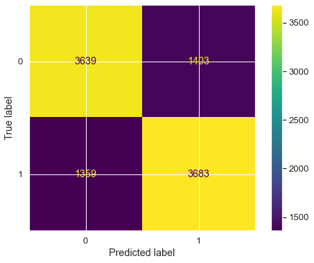

```python
# Classification Report and Confusion Matrix - Train data

print(classification_report(y_train, y_train_grid_predict))

plot_confusion_matrix(best_LR_mob_model, x_train, y_train)
```

```
              precision    recall  f1-score   support

           0       0.95      0.72      0.82      2179
           1       0.32      0.78      0.46       371

    accuracy                           0.73      2550
   macro avg       0.64      0.75      0.64      2550
weighted avg       0.86      0.73      0.77      2550
```

```
<sklearn.metrics._plot.confusion_matrix.ConfusionMatrixDisplay at 0x24010fec8e0>
```

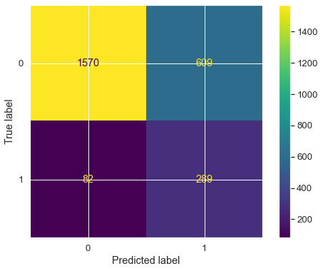

```python
# Classification Report and Confusion Matrix - Test data

print(classification_report(y_test, y_test_grid_predict))

plot_confusion_matrix(best_LR_mob_model, x_test, y_test)
```

### KNN Model (k-nearest neighbors)

We will be building KNN model on re-sampled train sets.

```python
# Importing KNeighboursClassifier

KNN_mob_model = KNeighborsClassifier()

KNN_mob_model.fit(x_train, y_train)
```

```
KNeighborsClassifier()
```

### Model Evaluation - Classification Report, Confusion Matrix, AUC ROC -

```python
#let us predict the model on train set and check the model score

predicted_labels = KNN_mob_model.predict(x_train)

KNN_mob_model_score = KNN_mob_model.score(x_train, y_train)

KNN_mob_model_score
```

```
0.9737207457358191
```

```
Classification Report

              precision    recall  f1-score   support

           0       1.00      0.95      0.97      5042
           1       0.95      1.00      0.97      5042

    accuracy                           0.97     10084
   macro avg       0.97      0.97      0.97     10084
weighted avg       0.97      0.97      0.97     10084
```

```
<sklearn.metrics._plot.confusion_matrix.ConfusionMatrixDisplay at 0x24010d72970>
```

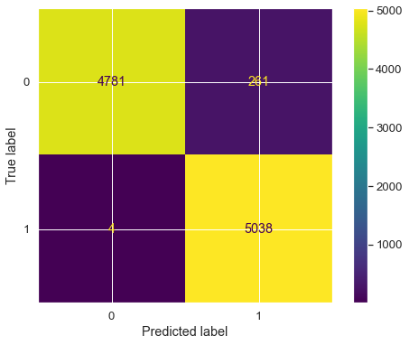

```python
# For train data

print('Classification Report\n')

print(metrics.classification_report(y_train, predicted_labels))

plot_confusion_matrix(KNN_mob_model, x_train, y_train)
```

```python
#let us predict the model on test set and check the model score

predicted_labels_test = KNN_mob_model.predict(x_test)

KNN_mob_model_score_test = KNN_mob_model.score(x_test, y_test)

KNN_mob_model_score_test
```

```
0.9050980392156863
```

```
Classification Report

              precision    recall  f1-score   support

           0       0.99      0.90      0.94      2179
           1       0.61      0.96      0.75       371

    accuracy                           0.91      2550
   macro avg       0.80      0.93      0.84      2550
weighted avg       0.94      0.91      0.91      2550
```

```
<sklearn.metrics._plot.confusion_matrix.ConfusionMatrixDisplay at 0x240110407f0>
```

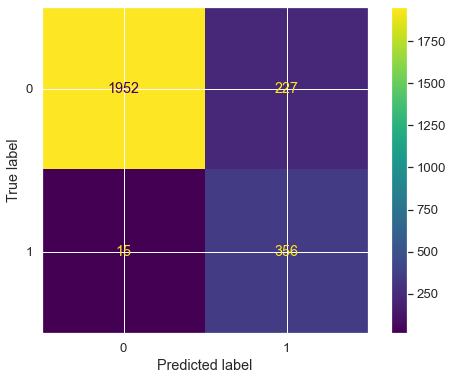

```python
# For test data

print('Classification Report\n')

print(metrics.classification_report(y_test, predicted_labels_test))

plot_confusion_matrix(KNN_mob_model, x_test, y_test)
```

### AUC ROC Curve on Train and Test data :-

```
Area Under Curve: 1.000
```

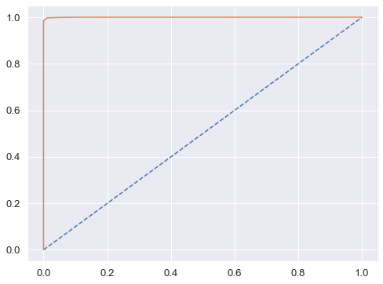

```python
KNN_probs_train = KNN_mob_model.predict_proba(x_train)

KNN_probs_train = KNN_probs_train[:, 1]

auc=roc_auc_score(y_train, KNN_probs_train)

print("Area Under Curve: %.3f " % auc)
train_fpr ,train_tpr, train_thresholds= roc_curve(y_train, KNN_probs_train)
plt.plot([0,1],[0,1],linestyle='--')
plt.plot(train_fpr,train_tpr);
```

```
Area Under Curve: 0.979
```

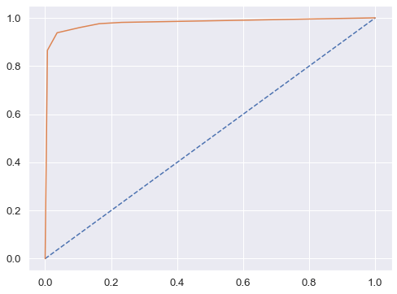

```python
KNN_probs_test = KNN_mob_model.predict_proba(x_test)

KNN_probs_test = KNN_probs_test[:, 1]

auc=roc_auc_score(y_test, KNN_probs_test)

print("Area Under Curve: %.3f " % auc)
test_fpr ,test_tpr, test_thresholds= roc_curve(y_test, KNN_probs_test)
plt.plot([0,1],[0,1],linestyle='--')
plt.plot(test_fpr,test_tpr);
```

### Naive Bayes Model

```python
# Fit the model into training data

NB_mob_model = GaussianNB()

NB_mob_model.fit(x_train, y_train)
```

```
GaussianNB()
```

### Model Evaluation - Classification Report and Confusion Matrix -

```python
# Prediction - on Train and Test data

NB_train_predict = NB_mob_model.predict(x_train)
NB_test_predict = NB_mob_model.predict(x_test)

print("Model Accuracy on Train Data: {0:.2f}".format(metrics.accuracy_score(y_train, NB_train_predict)))
print("Model Accuracy on Test Data: {0:.2f}".format(metrics.accuracy_score(y_test, NB_test_predict)))
```

```
Model Accuracy on Train Data: 0.68
Model Accuracy on Test Data: 0.63
```

```
Classification Report for Train Data:

              precision    recall  f1-score   support

           0       0.70      0.62      0.66      5042
           1       0.66      0.74      0.70      5042

    accuracy                           0.68     10084
   macro avg       0.68      0.68      0.68     10084
weighted avg       0.68      0.68      0.68     10084
```

```
<sklearn.metrics._plot.confusion_matrix.ConfusionMatrixDisplay at 0x2400e1f88b0>
```

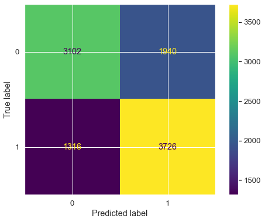

```python
# Classification Report and Confusion Matrix for Train Data

print('Classification Report for Train Data:\n')

print(metrics.classification_report(y_train, NB_train_predict))

plot_confusion_matrix(NB_mob_model, x_train, y_train)
```

```
Classification Report for test Data:

              precision    recall  f1-score   support

           0       0.93      0.61      0.74      2179
           1       0.24      0.73      0.36       371

    accuracy                           0.63      2550
   macro avg       0.58      0.67      0.55      2550
weighted avg       0.83      0.63      0.68      2550
```

```
<sklearn.metrics._plot.confusion_matrix.ConfusionMatrixDisplay at 0x24011005a30>
```

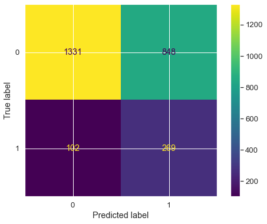

```python
# Classification Report and Confusion Matrix for test Data

print('Classification Report for test Data:\n')

print(metrics.classification_report(y_test, NB_test_predict))

plot_confusion_matrix(NB_mob_model, x_test, y_test)
```

### Random Forest Classifier -

```python
# Calling the Random Forest Classifier with hyper-parameters

rfcl_mob = RandomForestClassifier(n_estimators=301,
                                  oob_score = True,
                                  max_depth = 10,
                                  max_features = 5,
                                  min_samples_leaf = 50,
                                  min_samples_split=110)

rfcl_mob = rfcl_mob.fit(x_train, y_train)
```

#### Hyper-parameters for the classifier :

- n_estimators = number of trees, that we want to build within the RandomForestClassifier.
- Out of bag (OOB) score is a way of validating the Random forest model. It is computed as the number of correctly predicted rows from the out of bag sample.
- max_features will be used to select randomly features from the available number of features.

```python
rfcl_mob
```

```
RandomForestClassifier(max_depth=10, max_features=5, min_samples_leaf=50,
                       min_samples_split=110, n_estimators=301, oob_score=True)
```

### OOB Score (Out of Bag) and Error Rate for Random Forest Classifier -

The OOB score is computed as the number of correctly predicted rows from the out of bag sample.

```python
rfcl_mob.oob_score_
```

```
0.8731654105513685
```

```python
#Checking the error rate in %:

print('Error_rate(in %) :', 1- (rfcl_mob.oob_score_)) #OOB Error is the number of wrongly classifying the OOB Sample.
```

```
Error_rate(in %) : 0.12683458944863146
```

For the above specified grid parameters, we got the rfcl_mob model with oob score around 87% and error rate 13%, which shows the model is good to go for further evaluation.

### Getting the Feature Importances :-

Feature Importance refers to techniques that calculate a score for all the input features for a given model — the scores simply represent the “importance” of each feature. A higher score means that the specific feature will have a larger effect on the model that is being used to predict a certain variable.

```python
print (pd.DataFrame(rfcl_mob.feature_importances_,
                    columns = ["Imp"],
                    index = x_train.columns).sort_values('Imp',ascending=False))
```

```
                             Imp
Following_CP_Yes            0.17
TL_rec_on_OS_checkin        0.17
Adult_flag_1                0.12
YA_view_on_CP               0.10
Week_since_last_OS_checkin  0.09
TL_done_on_OS_checkin       0.08
DA_mins_spend_on_CP         0.07
YA_OS_checkin               0.07
Members_in_fam              0.04
YA_comment_on_CP            0.04
Travelling_network_rating_3 0.02
Travelling_network_rating_4 0.02
Travelling_network_rating_2 0.01
Working_flag_Yes            0.00
Pref_loc_type_Big_Cities    0.00
Pref_loc_type_Financial     0.00
Pref_loc_type_Medical       0.00
Pref_loc_type_Entertainment 0.00
Pref_loc_type_Other         0.00
Pref_device_Mobile          0.00
```

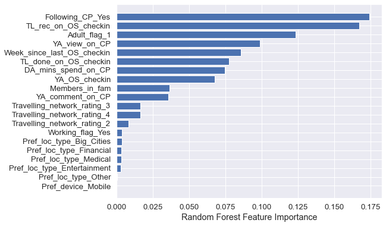

```python
# let us Visualize this in a sorted manner :

sorted_idx = rfcl_mob.feature_importances_.argsort()
plt.barh(x_train.columns[sorted_idx], rfcl_mob.feature_importances_[sorted_idx])
plt.xlabel("Random Forest Feature Importance")
```

- We can clearly see that which are the most important features that will have a larger effect on the model that is being used to predict a certain variable.
- By above calculation we can say that our top 5 features are:
1. Following_CP_Yes : 0.17
2. TL_rec_on_OS_checkin : 0.17
3. Adult_flag_1 : 0.12
4. YA_view_on_CP : 0.10
5. Week_since_last_OS_checkin : 0.09

### Model Performance on Train and Test data -

```python
# Prediction on Train Data

rfcl_mob_train_predict = rfcl_mob.predict(x_train)

print("Model Accuracy on Train Data: {0:.2f}".format(metrics.accuracy_score(y_train, rfcl_mob_train_predict)))
```

```
Model Accuracy on Train Data: 0.89
```

```python
# Prediction on Test Data

rfcl_mob_test_predict = rfcl_mob.predict(x_test)

print("Model Accuracy on Test Data: {0:.2f}".format(metrics.accuracy_score(y_test, rfcl_mob_test_predict)))
```

```
Model Accuracy on Test Data: 0.86
```

### Classification Report and Confusion Matrix -

```
Classification Report for Train Data:

              precision    recall  f1-score   support

           0       0.89      0.89      0.89      5042
           1       0.89      0.89      0.89      5042

    accuracy                           0.89     10084
   macro avg       0.89      0.89      0.89     10084
weighted avg       0.89      0.89      0.89     10084
```

```
<sklearn.metrics._plot.confusion_matrix.ConfusionMatrixDisplay at 0x2400e4d0610>
```

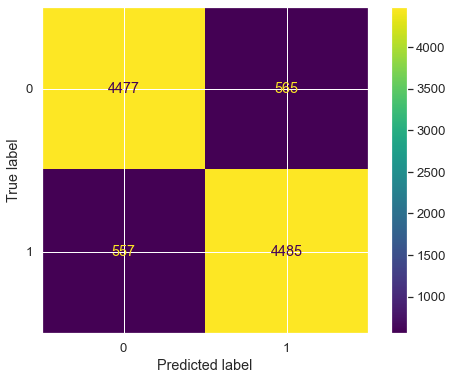

```python
print('Classification Report for Train Data:\n')

print(metrics.classification_report(y_train, rfcl_mob_train_predict))

plot_confusion_matrix(rfcl_mob, x_train, y_train)
```

```
Classification Report for Test Data:

              precision    recall  f1-score   support

           0       0.96      0.88      0.91      2179
           1       0.51      0.77      0.61       371

    accuracy                           0.86      2550
   macro avg       0.73      0.82      0.76      2550
weighted avg       0.89      0.86      0.87      2550
```

```
<sklearn.metrics._plot.confusion_matrix.ConfusionMatrixDisplay at 0x2400e52f310>
```

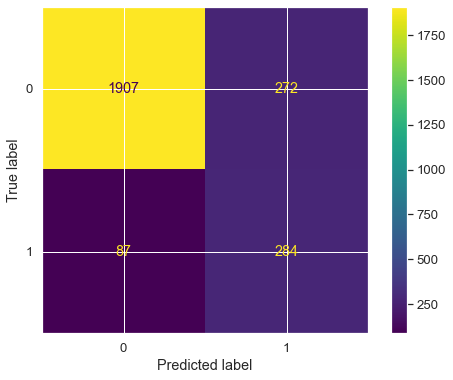

```python
print('Classification Report for Test Data:\n')

print(metrics.classification_report(y_test, rfcl_mob_test_predict))

plot_confusion_matrix(rfcl_mob, x_test, y_test)
```

### AUC ROC Curve on Train and Test data -

```
Area Under Curve: 0.956
```

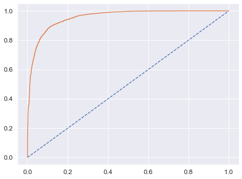

```python
# AUC ROC Curve on train data

probs_train_mob = rfcl_mob.predict_proba(x_train)

probs_train_mob = probs_train_mob[:, 1]

auc_for_train_mob = roc_auc_score(y_train, probs_train_mob)


print("Area Under Curve: %.3f " % auc_for_train_mob)
train_fpr ,train_tpr, train_thresholds= roc_curve(y_train, probs_train_mob)
plt.plot([0,1],[0,1],linestyle='--')
plt.plot(train_fpr,train_tpr);
```

```
Area Under Curve: 0.894
```

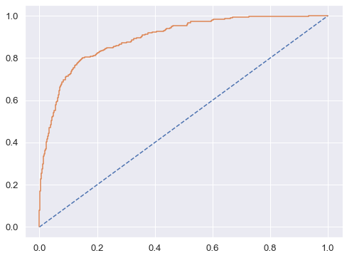

```python
# AUC ROC Curve on test data

probs_test_mob = rfcl_mob.predict_proba(x_test)

probs_test_mob = probs_test_mob[:, 1]

auc_for_test_mob = roc_auc_score(y_test, probs_test_mob)


print("Area Under Curve: %.3f " % auc_for_test_mob)
test_fpr ,test_tpr, test_thresholds= roc_curve(y_test, probs_test_mob)
plt.plot([0,1],[0,1],linestyle='--')
plt.plot(test_fpr,test_tpr);
```

### let us Now use Ensemble techniques : Bagging, Ada Boosting, GradientBoost :-

### Bagging - Random Forest (with Bagging as Ensemble Method) -

```python
#let us first look by use Bagging

#we will be using random forest as base_estimator

bgcl_mob = BaggingClassifier(base_estimator=rfcl_mob, n_estimators=50,random_state=1)
```

```python
# Fit the model into training data
bgcl_mob = bgcl_mob.fit(x_train, y_train)
```

### Model Performance -

```python
# let us predict on test set

y_train_predict = bgcl_mob.predict(x_train)

print('Accuracy of the model on Train Data:',bgcl_mob.score(x_train , y_train))
```

```
Accuracy of the model on Train Data: 0.8530345101150337
```

```python
# let us predict on test set

y_test_predict = bgcl_mob.predict(x_test)

print('Accuracy of the model on Test Data:',bgcl_mob.score(x_test , y_test))
```

```
Accuracy of the model on Test Data: 0.8345098039215686
```

### Classification Report and Confusion Matrix -

```
Classification Report for Train Data:

              precision    recall  f1-score   support

           0       0.85      0.86      0.85      5042
           1       0.86      0.84      0.85      5042

    accuracy                           0.85     10084
   macro avg       0.85      0.85      0.85     10084
weighted avg       0.85      0.85      0.85     10084
```

```
<sklearn.metrics._plot.confusion_matrix.ConfusionMatrixDisplay at 0x24012149340>
```

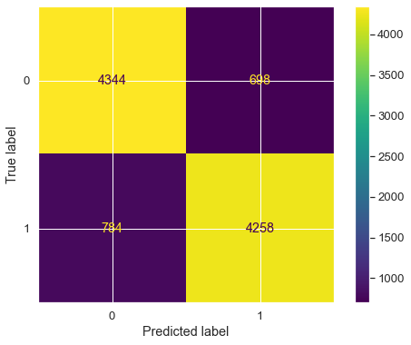

```python
# For Train Data

print('Classification Report for Train Data:\n')

print(metrics.classification_report(y_train, y_train_predict))

plot_confusion_matrix(bgcl_mob, x_train, y_train)
```

```
Classification Report for test Data:

              precision    recall  f1-score   support

           0       0.95      0.85      0.90      2179
           1       0.46      0.75      0.57       371

    accuracy                           0.83      2550
   macro avg       0.71      0.80      0.73      2550
weighted avg       0.88      0.83      0.85      2550
```

```
<sklearn.metrics._plot.confusion_matrix.ConfusionMatrixDisplay at 0x2400e6cfb80>
```

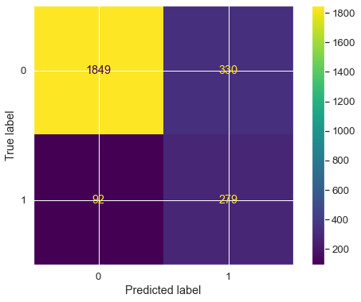

```python
# For test Data

print('Classification Report for test Data:\n')

print(metrics.classification_report(y_test, y_test_predict))

plot_confusion_matrix(bgcl_mob, x_test, y_test)
```

By using the Bagging, we can observe that the model performance on test data has not improved too much. Now we will use Ada-Boosting and then compare the model once again.

### Ada Boosting

```python
# Calling the Ada-boosting classifier

# With base_estimator = Random Forest

abcl_mob = AdaBoostClassifier(base_estimator=rfcl_mob, n_estimators= 50, random_state=1)
```

```python
#fit the model to the train data

abcl_mob = abcl_mob.fit(x_train, y_train)
```

### Model Evaluation -

```python
# Prediction on - Train data

abcl_mob_train_predict = abcl_mob.predict(x_train)

print('Accuracy of the Ada_Boosting Model on Train Data:',abcl_mob.score(x_train , y_train))
```

```
Accuracy of the Ada_Boosting Model on Train Data: 0.9982149940499802
```

```python
# Prediction on - Test data

abcl_mob_test_predict = abcl_mob.predict(x_test)

print('Accuracy of the Ada_Boosting Model on Test Data:',abcl_mob.score(x_test , y_test))
```

```
Accuracy of the Ada_Boosting Model on Test Data: 0.9666666666666667
```

### Classification Report and Confusion Matrix -

```
Classification Report for Train Data:

              precision    recall  f1-score   support

           0       1.00      1.00      1.00      5042
           1       1.00      1.00      1.00      5042

    accuracy                           1.00     10084
   macro avg       1.00      1.00      1.00     10084
weighted avg       1.00      1.00      1.00     10084
```

```
<sklearn.metrics._plot.confusion_matrix.ConfusionMatrixDisplay at 0x23449415cd0>
```

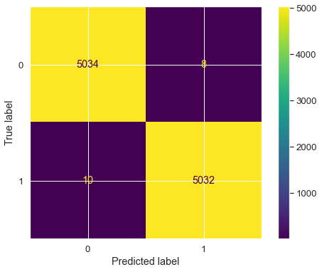

```python
# For Train Data

print('Classification Report for Train Data:\n')

print(metrics.classification_report(y_train, abcl_mob_train_predict))

plot_confusion_matrix(abcl_mob, x_train, y_train)
```

```
Classification Report for test Data:

              precision    recall  f1-score   support

           0       0.98      0.98      0.98      2179
           1       0.90      0.87      0.88       371

    accuracy                           0.97      2550
   macro avg       0.94      0.92      0.93      2550
weighted avg       0.97      0.97      0.97      2550
```

```
<sklearn.metrics._plot.confusion_matrix.ConfusionMatrixDisplay at 0x234496094c0>
```

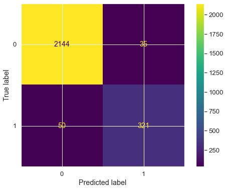

```python
# For Test Data

print('Classification Report for test Data:\n')

print(metrics.classification_report(y_test, abcl_mob_test_predict))

plot_confusion_matrix(abcl_mob, x_test, y_test)
```

### Gradient Boost

- Gradient boosting algorithm is one of the most powerful algorithms in the field of machine learning. As we know that the errors in machine learning algorithms are broadly classified into two categories i.e. Bias Error and Variance Error. As gradient boosting is one of the boosting algorithms it is used to minimize bias error of the model.
- Unlike, Ada-boosting algorithm, the base estimator in the gradient boosting algorithm cannot be mentioned by us. The base estimator for the Gradient Boost algorithm is fixed and i.e. Decision Stump. Like, Ada-Boost, we can tune the n_estimator of the gradient boosting algorithm. However, if we do not mention the value of n_estimator, the default value of n_estimator for this algorithm is 100.

```python
gbcl_mob = GradientBoostingClassifier(n_estimators = 150,random_state=1)

# Fit the model on Train data

gbcl_mob = gbcl_mob.fit(x_train, y_train)
```

### Model Evaluation -

```python
# Score on train and test set

print('Accuracy/Score of Gradient boost algorithm on Train Data:',gbcl_mob.score(x_train, y_train))
print('Accuracy/Score of Gradient boost algorithm on Test Data:',gbcl_mob.score(x_test, y_test))
```

```
Accuracy/Score of Gradient boost algorithm on Train Data: 0.9175922253074177
Accuracy/Score of Gradient boost algorithm on Test Data: 0.875686274509804
```

```python
# Prediction on Train and Test Data

gbcl_mob_train_predict = gbcl_mob.predict(x_train)
gbcl_mob_test_predict = gbcl_mob.predict(x_test)
```

### Classification Report and Confusion Matrix -

```
Classification Report for train Data:

              precision    recall  f1-score   support

           0       0.91      0.93      0.92      5042
           1       0.93      0.91      0.92      5042

    accuracy                           0.92     10084
   macro avg       0.92      0.92      0.92     10084
weighted avg       0.92      0.92      0.92     10084
```

```
<sklearn.metrics._plot.confusion_matrix.ConfusionMatrixDisplay at 0x24014595e20>
```

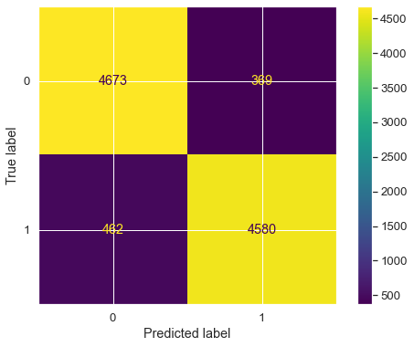

```python
# For Train Data

print('Classification Report for train Data:\n')

print(metrics.classification_report(y_train, gbcl_mob_train_predict))

plot_confusion_matrix(gbcl_mob, x_train, y_train)
```

```
Classification Report for test Data:

              precision    recall  f1-score   support

           0       0.94      0.91      0.93      2179
           1       0.56      0.66      0.61       371

    accuracy                           0.88      2550
   macro avg       0.75      0.79      0.77      2550
weighted avg       0.89      0.88      0.88      2550
```

```
<sklearn.metrics._plot.confusion_matrix.ConfusionMatrixDisplay at 0x2401c9c8d60>
```

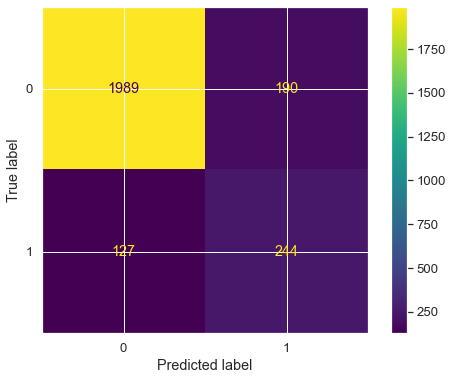

```python
 # For Test Data

print('Classification Report for test Data:\n')

print(metrics.classification_report(y_test, gbcl_mob_test_predict))

plot_confusion_matrix(gbcl_mob, x_test, y_test)
```

- Gradient Boosting Algorithm isn't performing very good on test data, as we can see that the accuracy is good 88% but with recall 66% for the minority class (1), we cannot say that it is a good predictor.
- The value of True Positives is 244, that means the model is able to predict correctly 244 times out of 371, and 127 times it is predicting incorrectly, which is not a good score.
- But this model is able to predict the majority class (0) correctly most of the times.